# Hedonic Home Price Prediction

Jonathon Sun, Johnathan Clementi a.k.a. John^2

9/29/2021

# Introduction

The intent of this report is to use local intelligence to improve Zillow’s predictive model utilizing only OLS regression. We began with the internal characteristics of the house, such as number of finished square feet, the number of bedrooms, and the number of bathrooms. We then engineered features that measured the average distance of amenities and public services such as grocery stores, fire departments, and schools. Further, we accounted for the spatial processes at play by creating fixed effects for the zip code, school district, and census tract in which the house resided. The resulting model was not as predicatively powerful as the Zillow Zestimate, and as such, we would recommend further development and testing on this model before it is deployed to the public.

# Data

The house sales data obtained for this study were obtained from the Boulder County Assessor’s Property Sales and Data download site. This dataset holds information on a house’s internal characteristics such as the total finished square feet, type of heating apparatus, and whether the house has a garage or not. Further, for this study, each house was assigned its own unique identifier, known as the MUSA_ID. However, a robust model would not be effective if it only had these individual property characteristics to predict on.  
To account for the public services and amenities that could affect house prices, data were retrieved from the City of Boulder, Boulder County, and Data Axle reference solutions, the last of which is a service that collects and provides business data to libraries. For this study, Data Axle was quite useful in providing data on various groups of businesses, such as police, fire, and EMT departments, shopping malls, museums and schools, and marijuana dispensaries. Finally, data were collected to measure and account for the spatial processes that are at play with house prices. These fixed effects take into consideration points that lie within a designated boundary. For example, all houses in a particular zip code would undergo a similar fixed effect because they all inhabit that zip code. In contrast, the nearest neighbor calculates the distance between two points and takes the average of those distances by nearest neighbor value.  
Below, we dive into the specifics of the most important datasets that we incorporated.

## Fixed Effects

The fixed effects data that we selected include the 2019 census tract data, bounder county school districts, Boulder City limits and Boulder County zip codes. These are all fixed effects as they represent spaces that the points inhabit and are shaped by. Some of these fixed effects will be engineered to provide more in-depth analysis.

### Census 2019

The first fixed effect variables that we looked at was census tract. With the census tract data, we pulled variables on Race and Median age. Race was important as a fixed effect to predict housing price, people with similar racial categories often move into similar spaces. Age was important because people may be interested moving into areas with similarly aged people.

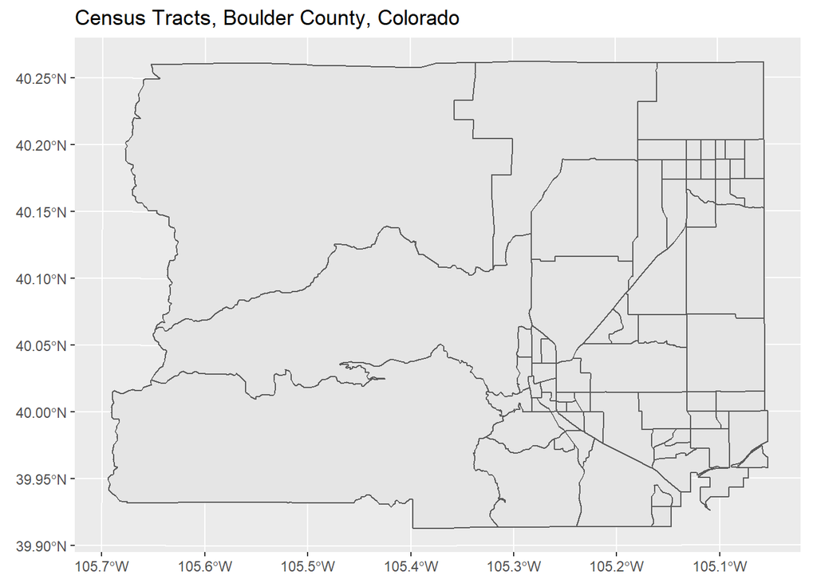

```r
#variables on frequency of Race
Variables <- load_variables(2019,
                            "acs5",
                            cache = TRUE) %>%
  mutate(Merge_name = paste(name,"E", sep ="")) %>%
  filter(grepl("RACE", concept)) %>%
  filter(!grepl("AGE", concept)) %>%
  slice(1:10)

#variable median age, men and women not by race
A <- load_variables(2019,
                    "acs5",
                    cache = TRUE) %>%
  mutate(Merge_name = paste(name,"E", sep ="")) %>%
  filter(grepl("MEDIAN", concept)) %>%
  slice(1:3)

#Median Household Income
B <- load_variables(2019,
                    "acs5",
                    cache = TRUE) %>%
  mutate(Merge_name = paste(name,"E", sep ="")) %>%
  filter(grepl("MEDIAN INCOME", concept)) %>%
  slice(1)

# Cost of living
C <- load_variables(2019,
                    "acs5",
                    cache = TRUE) %>%
  mutate(Merge_name = paste(name,"E", sep ="")) %>%
  filter(grepl("COST", concept)) %>%
  slice(1:19)

Variables <- bind_rows(Variables, A, B, C)

# Pull census data using tidycensus
# Read in census tracts

acsTractsCol.2019.sf <- get_acs(geography = "tract",
        year = 2019,
        variables = Variables$name,
        state="Colorado",
        county= c("Boulder"),
        geometry=T,
        output = "wide") %>%
  st_transform(CO_statePlaneCentral)%>%
  dplyr::select (GEOID, NAME, all_of(paste0(Variables$name,"E"))) %>%
  rename(Total_pop = Variables$Merge_name[1],
         White_pop = Variables$Merge_name[2],
         Black_pop = Variables$Merge_name[3],
         American_Indian_pop = Variables$Merge_name[4],
         Asian_pop = Variables$Merge_name[5],
         Hawiian_PI_pop = Variables$Merge_name[6],
         OtherRace_pop = Variables$Merge_name[7],
         two_or_more_pop = Variables$Merge_name[8],
         two_other_pop = Variables$Merge_name[9],
         two_or_more_exclude_pop = Variables$Merge_name[10],
         Median_age = Variables$Merge_name[11],
         Median_Male_age = Variables$Merge_name[12],
         Median_Female_age = Variables$Merge_name[13],
         Median_Income = Variables$Merge_name[14],
         MortgagesTotal_mortgage = Variables$Merge_name[15],
         MortgagesHas_mortgage = Variables$Merge_name[16],
         Mortgage200Less_mortgage = Variables$Merge_name[17],
         Mortgage200_299_mortgage = Variables$Merge_name[18],
         Mortgage300_399_mortgage = Variables$Merge_name[19],
         Mortgage400_499_mortgage = Variables$Merge_name[20],
         Mortgage500_599_mortgage = Variables$Merge_name[21],
         Mortgage600_699_mortgage = Variables$Merge_name[22],
         Mortgage700_799_mortgage = Variables$Merge_name[23],
         Mortgage800_899_mortgage = Variables$Merge_name[24],
         Mortgage900_999_mortgage = Variables$Merge_name[25],
         Mortgage1000_1249_mortgage = Variables$Merge_name[26],
         Mortgage1250_1499_mortgage = Variables$Merge_name[27],
         Mortgage1500_1999_mortgage = Variables$Merge_name[28],
         Mortgage2000_2499_mortgage = Variables$Merge_name[29],
         Mortgage2500_2999_mortgage = Variables$Merge_name[30],
         Mortgage3000_3499_mortgage = Variables$Merge_name[31],
         Mortgage3500_3999_mortgage = Variables$Merge_name[32],
         Mortgage4000_mortgage = Variables$Merge_name[33])


acsTractsCol.2019.sf <- mutate(acsTractsCol.2019.sf, TractID = row_number())


ggplot() +
 geom_sf(data = acsTractsCol.2019.sf)+
 labs(title = "Census Tracts, Boulder County, Colorado")
```

```r
# Assign a school district to each home
# Help document: https://gis.stackexchange.com/questions/133625/checking-if-points-fall-within-polygon-shapefile
studentData <- studentData %>%
  mutate(
    TractID = as.integer(st_intersects(geometry,acsTractsCol.2019.sf)))
    #,
    #schoolDist_name = if_else(is.na(District), "", acsSchoolDistrctssCol.2019.sf$NAME[District])
```

### Boulder City Fixed Effect

We thought it would be important to consider which points were within Boulder City limits. These points were engineered to consider if they were or were not within the city limits.

```r
boulderCityLimits <- st_read("https://opendata.arcgis.com/datasets/955e7a0f52474b60a9866950daf10acb_0.geojson") %>%
  st_transform(st_crs(acsTractsCol.2019.sf)) %>%
  mutate(inCity = 1)

# Determine if a house is within the city or not - used for cases in which only city data is available
studentData <- studentData %>%
  mutate(withinCity = as.integer(st_intersects(geometry,boulderCityLimits)))

studentData <- studentData %>%
  mutate(withinCity = replace_na(withinCity,"0"))

# Change withinCity from categorical (possible values of 1,2,3...) to binary (1 = within city, 0 = out of city)
studentData <- studentData %>%
  mutate(withinCity = ifelse(withinCity > 0, 1, 0))
```

### Boulder County School Districts

Another fixed effect that was included in the analysis was school district. The assumption that is being made with school district is that potential home buyers value general education and they believe that education will increase their own, or their children, human capital. School district data was also pulled from the American Community Survey data and overlapped by census tracts to ensure all the correct locations were used. Each point from the dataset was then assigned to a particular district.

```r
#Unified School District
acsSchoolDistrctssCol.2019.sf <- get_acs(geography = "school district (unified)",
        year = 2019,
        variables = Variables$name,
        state="Colorado",
        geometry=T,
        output = "wide") %>%
  st_transform(CO_statePlaneCentral) %>%
  dplyr::select (GEOID, NAME, all_of(paste0(Variables$name,"E")))


school_districts <- st_overlaps(st_union(acsTractsCol.2019.sf), acsSchoolDistrctssCol.2019.sf)
acsSchoolDistrctssCol.2019.sf <- acsSchoolDistrctssCol.2019.sf %>%
  slice(school_districts[[1]])

acsSchoolDistrctssCol.2019.sf <- mutate(acsSchoolDistrctssCol.2019.sf, id = row_number())


# Assign a school district to each home
# Help document: https://gis.stackexchange.com/questions/133625/checking-if-points-fall-within-polygon-shapefile
studentData <- studentData %>%
  mutate(
    District = paste0("District",as.integer(st_intersects(geometry,acsSchoolDistrctssCol.2019.sf)))
    #,
    #schoolDist_name = if_else(is.na(District), "", acsSchoolDistrctssCol.2019.sf$NAME[District])
  )


# ggplot() +
#  geom_sf(data = acsSchoolDistrctssCol.2019.sf,
#          fill = "red") +
#  geom_sf(data = st_union(acsTractsCol.2019.sf),
#         fill = "transparent")
```

### Boulder County Zip codes

Most people are not aware of what census tract they live in; however, census tract data provides more detail than zip codes do. As such we thought it was important to analyze the prices in each zip code. Zip codes are also strong predictors of future economic outcomes.

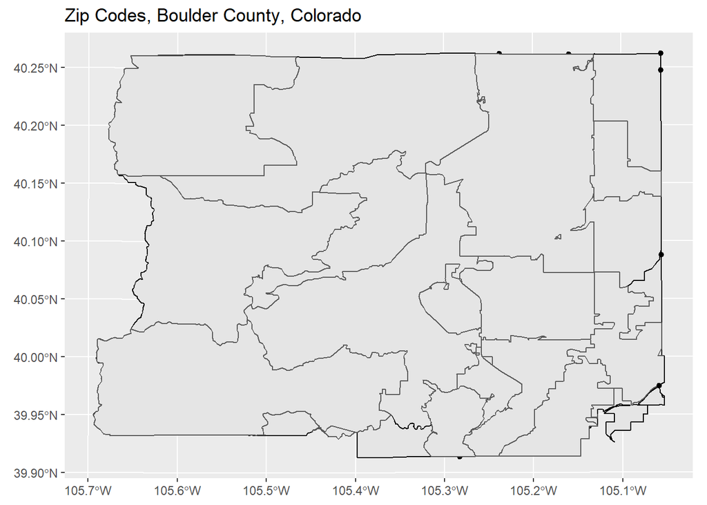

```r
#Zip Code
acsZipsCol.2019.sf <- get_acs(geography = "zcta",
        year = 2019,
        variables = Variables$name,
        geometry=T,
        output = "wide") %>%
  st_transform(CO_statePlaneCentral) %>%
  dplyr::select (GEOID, NAME, all_of(paste0(Variables$name,"E"))) %>%
  rename(Total_pop = Variables$Merge_name[1],
         White_pop = Variables$Merge_name[2],
         Black_pop = Variables$Merge_name[3],
         American_Indian_pop = Variables$Merge_name[4],
         Asian_pop = Variables$Merge_name[5],
         Hawiian_PI_pop = Variables$Merge_name[6],
         OtherRace_pop = Variables$Merge_name[7],
         two_or_more_pop = Variables$Merge_name[8],
         two_other_pop = Variables$Merge_name[9],
         two_or_more_exclude_pop = Variables$Merge_name[10],
         Median_age = Variables$Merge_name[11],
         Median_Male_age = Variables$Merge_name[12],
         Median_Female_age = Variables$Merge_name[13],
         Median_Income = Variables$Merge_name[14],
         MortgagesTotal_mortgage = Variables$Merge_name[15],
         MortgagesHas_mortgage = Variables$Merge_name[16],
         Mortgage200Less_mortgage = Variables$Merge_name[17],
         Mortgage200_299_mortgage = Variables$Merge_name[18],
         Mortgage300_399_mortgage = Variables$Merge_name[19],
         Mortgage400_499_mortgage = Variables$Merge_name[20],
         Mortgage500_599_mortgage = Variables$Merge_name[21],
         Mortgage600_699_mortgage = Variables$Merge_name[22],
         Mortgage700_799_mortgage = Variables$Merge_name[23],
         Mortgage800_899_mortgage = Variables$Merge_name[24],
         Mortgage900_999_mortgage = Variables$Merge_name[25],
         Mortgage1000_1249_mortgage = Variables$Merge_name[26],
         Mortgage1250_1499_mortgage = Variables$Merge_name[27],
         Mortgage1500_1999_mortgage = Variables$Merge_name[28],
         Mortgage2000_2499_mortgage = Variables$Merge_name[29],
         Mortgage2500_2999_mortgage = Variables$Merge_name[30],
         Mortgage3000_3499_mortgage = Variables$Merge_name[31],
         Mortgage3500_3999_mortgage = Variables$Merge_name[32],
         Mortgage4000_mortgage = Variables$Merge_name[33])


acsZipsCol.2019.sf <- acsZipsCol.2019.sf %>%
  st_intersection(st_union(acsTractsCol.2019.sf)) %>%
  st_sf()

# # boulderCo_flood <- COState_flood %>%
# #   st_intersection(st_union(acsTractsCol.2019.sf)) %>%
# #   st_sf()


# ggplot() +
#   geom_sf(data = acsZipsCol.2019.sf) +
#   geom_sf(data = studentData)

# zuocodeR package
acsZipsCol.2019 <- search_county('Boulder', 'CO')


# Assign a zipcode to each home
# Help document: https://gis.stackexchange.com/questions/133625/checking-if-points-fall-within-polygon-shapefile
studentData <- studentData %>%
  mutate(
    Zip = paste0("Zip",as.integer(st_intersects(geometry,acsZipsCol.2019.sf)))
    #zipcode = if_else(is.na(Zip), "", acsSchoolDistrctssCol.2019.sf$NAME[Zip])
  )

ggplot() +
  geom_sf(data = acsZipsCol.2019.sf) +
  labs(title = "Zip Codes, Boulder County, Colorado")
```

## Point Data

Although it is possible to pull buffered data to analyze data by fixed effects, the fixed effect data is often categorical or binary and does not provide the nuance in building a model. To remedy this, we selected found point data on floods, amenities, public services, and education resources nearby. The benefit of this point data is that numeric data can be used in the model to provide more detail.

### Flood Data

Other factors that were considered in this analysis was flood plain data. As storms become stronger due to climate change, homeowners are likely to be more sensitive to the proximity of a house to a flood plain. For this study, 100-year flood plain data for the State of Colorado were retrieved from FEMA and reduced to Boulder County. We then turned the flood plain regions into point data to calculate the nearest neighbor points for each house. However, it may have been better to process the data as a fixed effect by just determining if a house is within our outside of a 100-year floodplain.

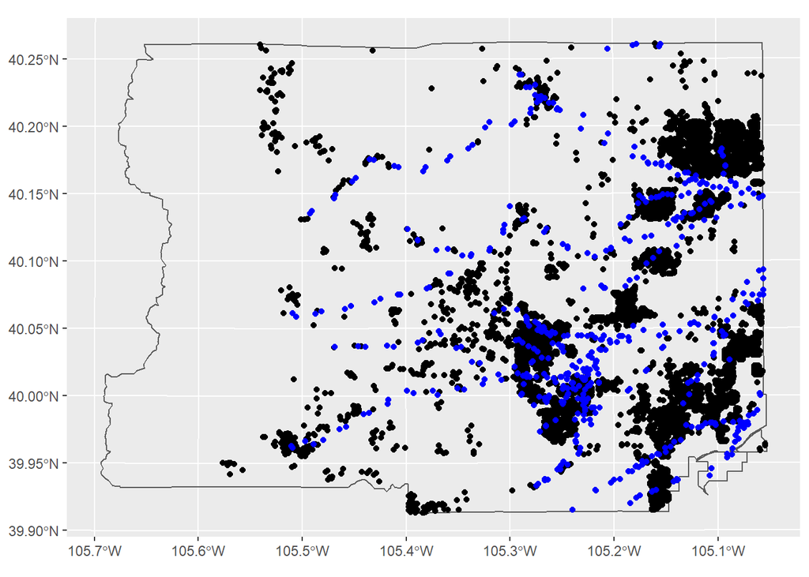

```r
# Locations of 100 Year floodplain within Boulder County
# Data originally for the whole state, subsetted to Boulder County via st_intersect
## https://geo.colorado.edu/catalog/47540-5ca228ffd43267000b8c7448
## About this dataset: https://open-data.bouldercolorado.gov/datasets/bfc343d63cf54831810b983b36ce6872_3/about

# # Process for creating Boulder County Flood Plains shp
# COState_flood <- st_read("CO_state_100yrFloodplains.geojson") %>%
#   st_transform(CO_statePlaneCentral)
#
# boulderCo_flood <- COState_flood %>%
#   st_intersection(st_union(acsTractsCol.2019.sf)) %>%
#   st_sf()
#
# # Create Geopackage for ease of transport - only one file
# st_write(boulderCo_flood, "boulderCo_100yrFloodZones.gpkg")

boulderCo_flood_gpkg <- st_read("boulderCo_100yrFloodZones.gpkg")

# Convert floodplain polygons to polylines
flood_boundaries <- st_boundary(boulderCo_flood_gpkg)

# Sample flood boundaries to get point data (used to pass to the nearest neighbor function)
flood_pts <- st_sample(flood_boundaries, size = 500, type = 'regular')
flood_pts <- st_cast(flood_pts, 'POINT')

ggplot() +
  geom_sf(data = st_union(acsTractsCol.2019.sf),
          fill = "transparent") +
  geom_sf(data = studentData) +
  geom_sf(data = flood_pts, color = "blue")
```

### Amenities

Amenity data was selected from Data Axle, and includes institutions such as groceries, restaurants, shopping maps, and recreational institutions. We thought that these institutions are not necessarily public services but provide benefits to the communities’ lifestyle.

### Public Services

Public services include hospitals, police departments, and fire departments. Although hospitals may not necessarily be public not-for-profit institutions, we thought it was important to include because of the impact that they have on public health and wellbeing of the community.

### Education

Educational variables included variables that provide educational benefits to the community. This primarily include public and private schools, neighborhoods, and universities. There is no weighted system that distinguishes the different types of educational institution in this dataset.

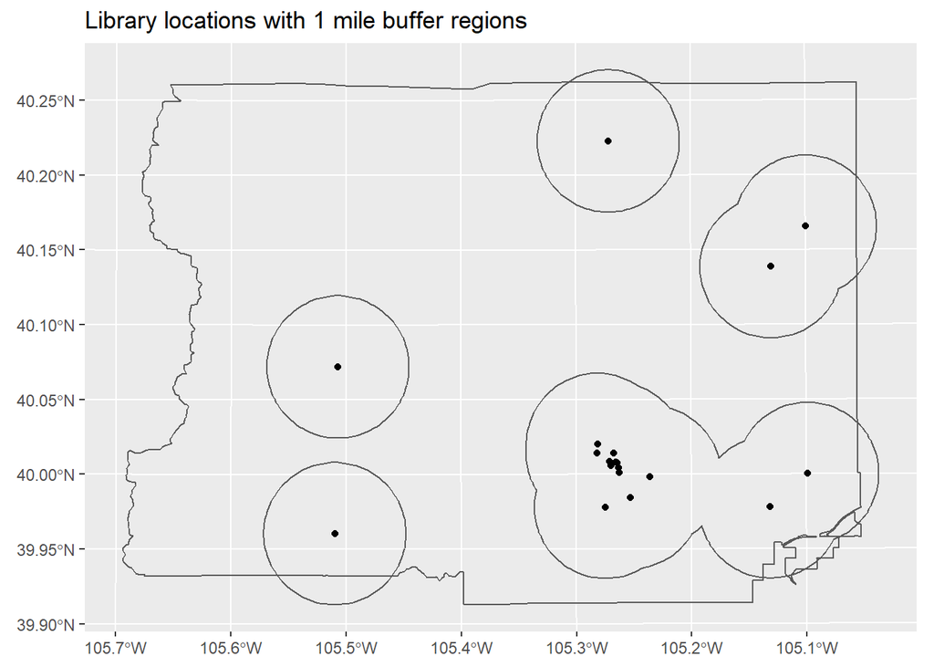

```r
# Locations of 19 libraries
## https://opendata-bouldercounty.hub.arcgis.com/datasets/libraries-2/explore?location=40.001009%2C-105.302539%2C11.28
Col_Library <- st_read("https://opendata.arcgis.com/datasets/7f4ea25ba87345e380d2e896611d2588_0.geojson") %>%
  st_transform(st_crs(acsTractsCol.2019.sf)) %>%
  select(c(Name, geometry))

Buffer_Library <- st_buffer(Col_Library, 5280) %>%
      mutate(Legend = "Buffer") %>%
      dplyr::select(Legend)

UnionBuffer_Library <- st_union(Buffer_Library)


ggplot() +
  geom_sf(data = st_union(acsTractsCol.2019.sf),
          fill = "transparent") +
  geom_sf(data = Col_Library) +
  geom_sf(data = UnionBuffer_Library,
          fill = "transparent") +
  labs(title = "Library locations with 1 mile buffer regions")
```

```r
# Grocery Stores from Data Axle
Grocery_Store <- read.csv("DataAxle_GroceryStores.csv") %>%
  st_as_sf(coords = c("Longitude", "Latitude"), crs = 4326, agr = "constant") %>%
  st_transform(CO_statePlaneCentral)

Buffer_Grocery <- st_buffer(Grocery_Store, 5280) %>%
      mutate(Legend = "Buffer") %>%
      dplyr::select(Legend)

#Buffer_Grocery_Union <- st_union(st_buffer(Grocery_Store, 5280) %>%
#      mutate(Legend = "Buffer") %>%
#      dplyr::select(Legend))

#ggplot() +
#  geom_sf(data = st_union(acsTractsCol.2019.sf),
#          fill = "transparent") +
#  geom_sf(data = Grocery_Store) +
#    geom_sf(data = Buffer_Grocery,
#          fill = "transparent") +
#  labs(title = "Grocery_Stores")

#Grocery.rings <-
#  st_join(st_centroid(dplyr::select(studentData, address)),
#          multipleRingBuffer(Buffer_Grocery, 5280, 2640)) %>%
#  st_drop_geometry() %>%
#  left_join(dplyr::select(studentData, address),
#            by=c("address"="address")) %>%
#  st_sf()

#Restaurants from DataAxle
Restaurants <- bind_rows(read.csv("DataAxle_Restaurants_1.csv"), read.csv("DataAxle_Restaurants_2.csv")) %>%
  st_as_sf(coords = c("Longitude", "Latitude"), crs = 4326, agr = "constant") %>%
  st_transform(CO_statePlaneCentral)

#Buffer_Restaurants <- st_union(st_buffer(Restaurants, 5280) %>%
#      mutate(Legend = "Buffer") %>%
#      dplyr::select(Legend))


#ggplot() +
#  geom_sf(data = st_union(acsTractsCol.2019.sf),
#          fill = "transparent") +
#  geom_sf(data = Restaurants) +
#    geom_sf(data = Buffer_Restaurants,
#          fill = "transparent") +
#  labs(title = "Restaurants")

#Education from DataAxle
Education <- read.csv("DataAxle_Education.csv") %>%
  st_as_sf(coords = c("Longitude", "Latitude"), crs = 4326, agr = "constant") %>%
  st_transform(CO_statePlaneCentral)

Buffer_Education <- st_union(st_buffer(Education, 5280) %>%
      mutate(Legend = "Buffer") %>%
      dplyr::select(Legend))


#Museums from DataAxle
Museums <- read.csv("DataAxle_Musuems.csv") %>%
  st_as_sf(coords = c("Longitude", "Latitude"), crs = 4326, agr = "constant") %>%
  st_transform(CO_statePlaneCentral)

Buffer_Museums <- st_union(st_buffer(Museums, 5280) %>%
      mutate(Legend = "Buffer") %>%
      dplyr::select(Legend))

###############################
# New Features as of 10.19.2021

#Recreation businesses from DataAxle
Recreation <- read.csv("DataAxle_Recreation.csv") %>%
  st_as_sf(coords = c("Longitude", "Latitude"), crs = 4326, agr = "constant") %>%
  st_transform(CO_statePlaneCentral)

Buffer_Recreation <- st_union(st_buffer(Recreation, 5280) %>%
      mutate(Legend = "Buffer") %>%
      dplyr::select(Legend))

#Police departments from DataAxle
PoliceDepartments <- read.csv("DataAxle_PoliceDepartments.csv") %>%
  st_as_sf(coords = c("Longitude", "Latitude"), crs = 4326, agr = "constant") %>%
  st_transform(CO_statePlaneCentral)

Buffer_PoliceDepartments <- st_union(st_buffer(PoliceDepartments, 5280) %>%
      mutate(Legend = "Buffer") %>%
      dplyr::select(Legend))

#Fire and EMT departments from DataAxle
FireandEMT <- read.csv("DataAxle_FireandEMT.csv") %>%
  st_as_sf(coords = c("Longitude", "Latitude"), crs = 4326, agr = "constant") %>%
  st_transform(CO_statePlaneCentral)

Buffer_FireandEMT <- st_union(st_buffer(FireandEMT, 5280) %>%
      mutate(Legend = "Buffer") %>%
      dplyr::select(Legend))

#Hospitals from DataAxle
Hospitals <- read.csv("DataAxle_Hospitals.csv") %>%
  st_as_sf(coords = c("Longitude", "Latitude"), crs = 4326, agr = "constant") %>%
  st_transform(CO_statePlaneCentral)

Buffer_Hospitals <- st_union(st_buffer(Hospitals, 5280) %>%
      mutate(Legend = "Buffer") %>%
      dplyr::select(Legend))

#ShoppingMalls from DataAxle
ShoppingMalls <- read.csv("DataAxle_ShoppingMalls.csv") %>%
  st_as_sf(coords = c("Longitude", "Latitude"), crs = 4326, agr = "constant") %>%
  st_transform(CO_statePlaneCentral)

Buffer_ShoppingMalls <- st_union(st_buffer(ShoppingMalls, 5280) %>%
      mutate(Legend = "Buffer") %>%
      dplyr::select(Legend))

#Marijuana Dispensaries from DataAxle
Dispensaries <- read.csv("DataAxle_MarijuanaDispensaries.csv") %>%
  st_as_sf(coords = c("Longitude", "Latitude"), crs = 4326, agr = "constant") %>%
  st_transform(CO_statePlaneCentral)

Buffer_Dispensaries <- st_union(st_buffer(Dispensaries, 5280) %>%
      mutate(Legend = "Buffer") %>%
      dplyr::select(Legend))
```

# Methods

## Feature Engineering

Once all the data were imported, the data were then transformed into a variety of ways to understand fixed effects and geographic distances.

### Census Tracts by Race

To utilize the census tracts these data were transformed into quartiles. The census tracts would represent the frequency of racial populations in that area. For example, for `White_quartile` column would predict for a specific quartile is the price, higher or lower. The same can be applied to other racial categories as well.

### Data classifications

Data from DataAxle were separated into three categories: amenities (grocery stores, restaurants, recreational institutions, shopping malls, and marijuana dispensaries), public services (police departments, fire departments, medical facilities), and education (educational institutions and museums).

### Nearest Neighbors

Each of these points were then used to find the five nearest neighbor value using the `nn_function`. Nn1 columns shows the distance to the direct nearest neighbor, the second takes the average distance of the two nearest neighbors, the third takes the average distance of the three nearest neighbors and so on.

To visually explore the data we’ve included some charts that will visually show the relationship between price and some of the variables that we have engineered and selected.

As the data is being explored, we removed the outlier `max`. This point would make some of the graphs challenging to view, because it would force the scale to be larger and as such more difficult to view the other points, because it does not accurately follow the trend of the other data.

### Internal Characteristics

The following figure below illustrates the spatial clustering of home prices by showing the price per finished square foot in the house. It is evident that there is clustering of higher-priced homes in and around the City of Boulder. We will need to account for this in our predictive model.

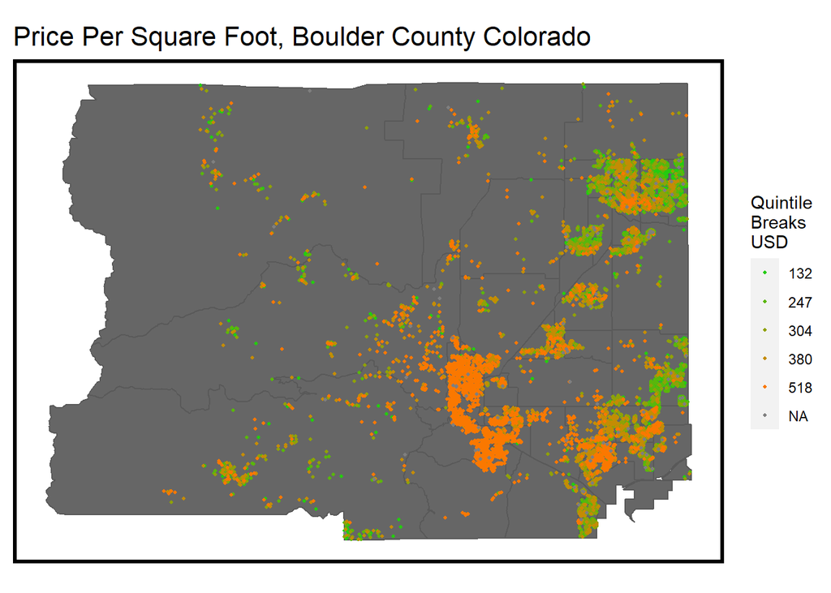

```r
ggplot() +
  geom_sf(data = acsTractsCol.2019.sf, fill = "grey40") +
  geom_sf(data = studentData, aes(colour = q5(pricePerSF)),
          show.legend = "point", size = .75) +
  scale_colour_manual(values = palette5,
                   labels=qBr(studentData,"pricePerSF"),
                   name="Quintile\nBreaks\nUSD") +
  labs(title="Price Per Square Foot, Boulder County Colorado") +
  mapTheme()
```

The following scatterplot below illustrates the correlation between house price, house age, how recently a house was improved (improvement age), and total square finished square feet. If a house has not been improved since it was built, improvement age will be 0.

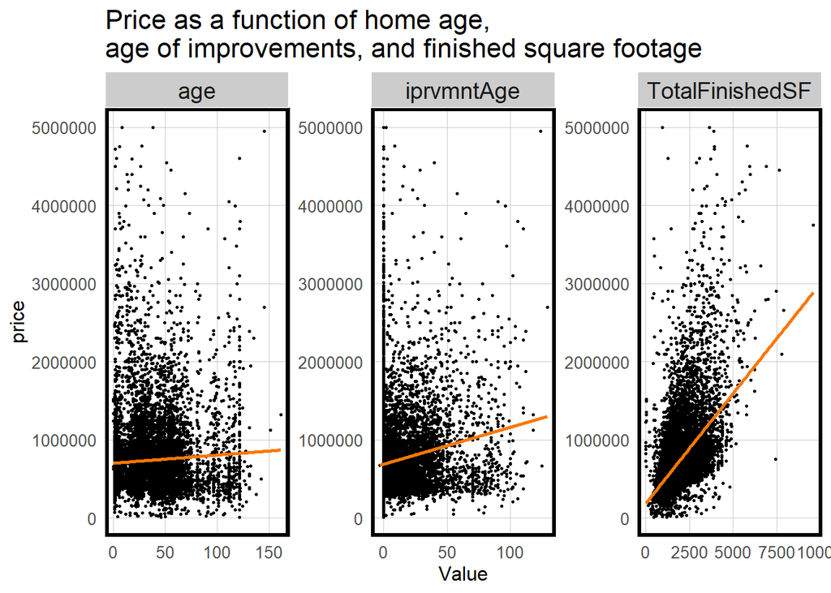

```r
st_drop_geometry(studentData) %>%
  dplyr::select(price, TotalFinishedSF, age, iprvmntAge) %>%
  filter(price <= 5000000, age < 500) %>%
  gather(Variable, Value, -price) %>%
   ggplot(aes(Value, price)) +
     geom_point(size = .5) + geom_smooth(method = "lm", se=F, colour = "#FA7800") +
     facet_wrap(~Variable, ncol = 3, scales = "free") +
     labs(title = "Price as a function of home age,\nage of improvements, and finished square footage") +
     plotTheme()
```

### Nearest Neighbor Averages Education

For this indicator, all nearest neighbors from 1-5 were selected and averaged. This data was than summarized to find the average per MUSA code and it’s associated price. These prices were than selected and plotted in the following charts. As expected the larger the average of the education variables nearest neighbor the lower the price of the property. Phrased differently, the further the property was from an educational institution the lower the price.

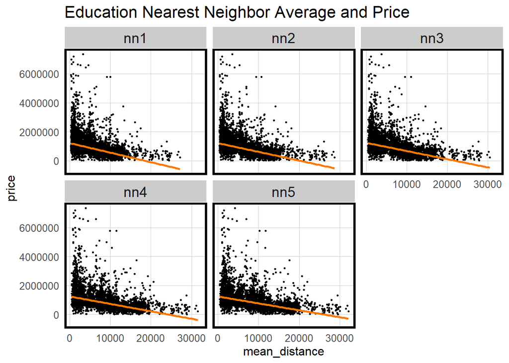

```r
bind_rows(
  st_drop_geometry(studentData) %>%
  filter(price < max(na.omit(studentData$price))) %>%
  select(1,MUSA_ID, intersect(starts_with("Edu"), ends_with("nn1"))) %>%
  select(!starts_with("flood_pts")) %>%
  mutate(nn = "nn1") %>%
  pivot_longer(cols = ends_with("nn1"),
               names_to = "Amenities",
               values_to = "Distance"),
  st_drop_geometry(studentData) %>%
  filter(price < max(na.omit(studentData$price))) %>%
  select(1,MUSA_ID, intersect(starts_with("Edu"), ends_with("nn2"))) %>%
  select(!starts_with("flood_pts")) %>%
      mutate(nn = "nn2") %>%
  pivot_longer(cols = ends_with("nn2"),
               names_to = "Amenities",
               values_to = "Distance"),
  st_drop_geometry(studentData) %>%
  filter(price < max(na.omit(studentData$price))) %>%
  select(1,MUSA_ID, intersect(starts_with("Edu"), ends_with("nn3"))) %>%
  select(!starts_with("flood_pts")) %>%
      mutate(nn = "nn3") %>%
  pivot_longer(cols = ends_with("nn3"),
               names_to = "Amenities",
               values_to = "Distance"),
  st_drop_geometry(studentData) %>%
  filter(price < max(na.omit(studentData$price))) %>%
  select(1,MUSA_ID, intersect(starts_with("Edu"), ends_with("nn4"))) %>%
  select(!starts_with("flood_pts")) %>%
      mutate(nn = "nn4") %>%
  pivot_longer(cols = ends_with("nn4"),
               names_to = "Amenities",
               values_to = "Distance"),
  st_drop_geometry(studentData) %>%
  filter(price < max(na.omit(studentData$price))) %>%
  select(1,MUSA_ID, intersect(starts_with("Edu"), ends_with("nn5"))) %>%
  select(!starts_with("flood_pts")) %>%
      mutate(nn = "nn5") %>%
  pivot_longer(cols = ends_with("nn5"),
               names_to = "Amenities",
               values_to = "Distance")) %>%
  group_by(MUSA_ID, nn, price) %>%
  summarize(mean_distance = mean(Distance)) %>%
    ggplot(aes(mean_distance, price)) +
    geom_point(size = .5) +
    geom_smooth(method = "lm", se = F, colour = "#FA7800") +
    labs(title = "Education Nearest Neighbor Average and Price") +
  facet_wrap(~nn) +
    plotTheme()
```

### Nearest Neighbors Averages Amenities

The amenities indicator also calculated the nearest neighbors from 1-5 and summarized by MUSA code and its associated price. It also found that the further away an amenity is from the property the lower the property value.

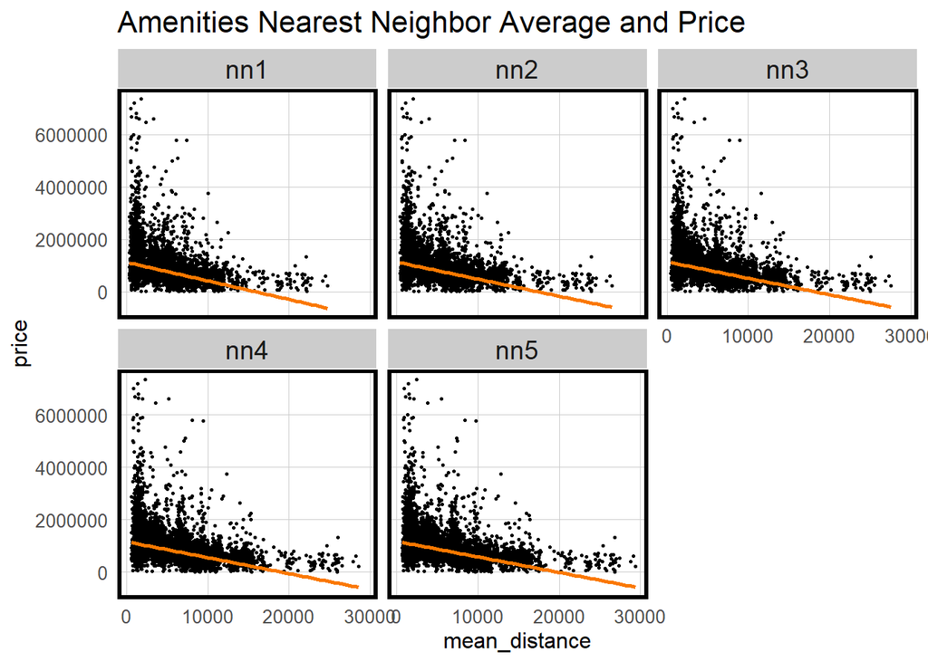

```r
bind_rows(
  st_drop_geometry(studentData) %>%
  filter(price < max(na.omit(studentData$price))) %>%
  select(1,MUSA_ID, intersect(starts_with("amenities"), ends_with("nn1"))) %>%
  select(!starts_with("flood_pts")) %>%
  mutate(nn = "nn1") %>%
  pivot_longer(cols = ends_with("nn1"),
               names_to = "Amenities",
               values_to = "Distance"),
  st_drop_geometry(studentData) %>%
  filter(price < max(na.omit(studentData$price))) %>%
  select(1,MUSA_ID, intersect(starts_with("amenities"), ends_with("nn2"))) %>%
  select(!starts_with("flood_pts")) %>%
      mutate(nn = "nn2") %>%
  pivot_longer(cols = ends_with("nn2"),
               names_to = "Amenities",
               values_to = "Distance"),
  st_drop_geometry(studentData) %>%
  filter(price < max(na.omit(studentData$price))) %>%
  select(1,MUSA_ID, intersect(starts_with("amenities"), ends_with("nn3"))) %>%
  select(!starts_with("flood_pts")) %>%
      mutate(nn = "nn3") %>%
  pivot_longer(cols = ends_with("nn3"),
               names_to = "Amenities",
               values_to = "Distance"),
  st_drop_geometry(studentData) %>%
  filter(price < max(na.omit(studentData$price))) %>%
  select(1,MUSA_ID, intersect(starts_with("amenities"), ends_with("nn4"))) %>%
  select(!starts_with("flood_pts")) %>%
      mutate(nn = "nn4") %>%
  pivot_longer(cols = ends_with("nn4"),
               names_to = "Amenities",
               values_to = "Distance"),
  st_drop_geometry(studentData) %>%
  filter(price < max(na.omit(studentData$price))) %>%
  select(1,MUSA_ID, intersect(starts_with("amenities"), ends_with("nn5"))) %>%
  select(!starts_with("flood_pts")) %>%
      mutate(nn = "nn5") %>%
  pivot_longer(cols = ends_with("nn5"),
               names_to = "Amenities",
               values_to = "Distance")) %>%
  group_by(MUSA_ID, nn, price) %>%
  summarize(mean_distance = mean(Distance)) %>%
    ggplot(aes(mean_distance,price)) +
    geom_point(size = .5) +
    geom_smooth(method = "lm", se = F, colour = "#FA7800") +
    labs(title = "Amenities Nearest Neighbor Average and Price") +
  facet_wrap(~nn) +
    plotTheme()
```

### Nearest Neighbors Averages Public Services

The last nearest neighbor indicator was public services. THis indicator serves the same purpose that the Amenities and Education indicator serves. The Public Services indicator showed that within the first nearest neighbor there is no decrease in price based on the distance from a public amenity; however, beyond the first nearest neighbor there is a difference in price.

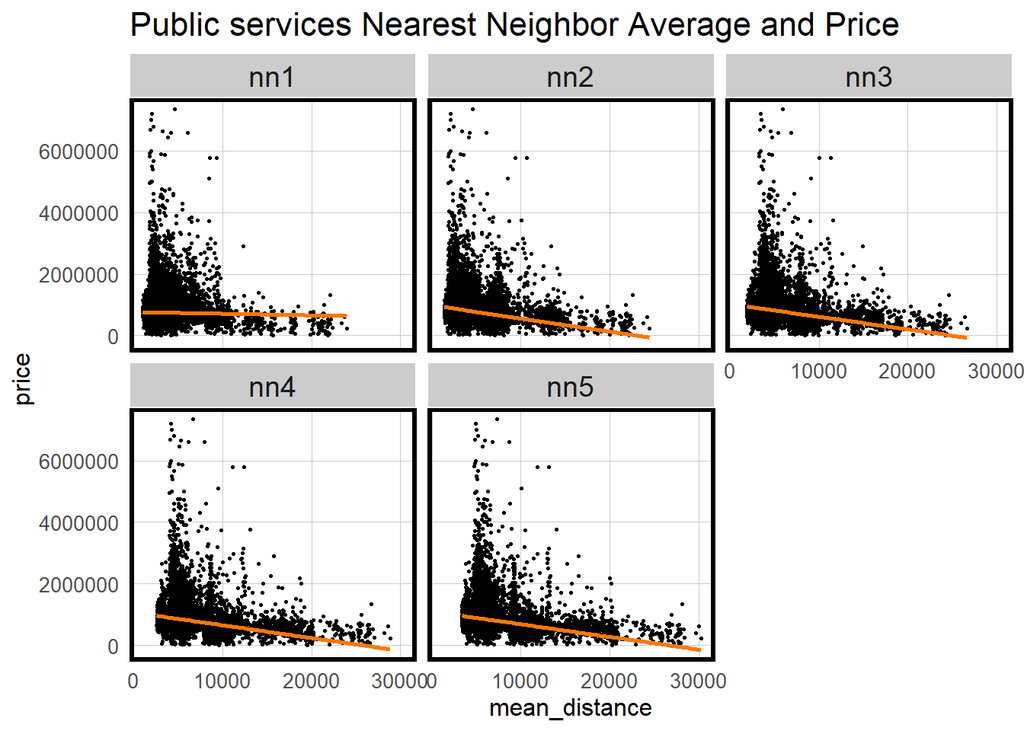

```r
bind_rows(
  st_drop_geometry(studentData) %>%
  filter(price < max(na.omit(studentData$price))) %>%
  select(1,MUSA_ID, intersect(starts_with("PS"), ends_with("nn1"))) %>%
  select(!starts_with("flood_pts")) %>%
  mutate(nn = "nn1") %>%
  pivot_longer(cols = ends_with("nn1"),
               names_to = "Amenities",
               values_to = "Distance"),
  st_drop_geometry(studentData) %>%
  filter(price < max(na.omit(studentData$price))) %>%
  select(1,MUSA_ID, intersect(starts_with("PS"), ends_with("nn2"))) %>%
  select(!starts_with("flood_pts")) %>%
      mutate(nn = "nn2") %>%
  pivot_longer(cols = ends_with("nn2"),
               names_to = "Amenities",
               values_to = "Distance"),
  st_drop_geometry(studentData) %>%
  filter(price < max(na.omit(studentData$price))) %>%
  select(1,MUSA_ID, intersect(starts_with("PS"), ends_with("nn3"))) %>%
  select(!starts_with("flood_pts")) %>%
      mutate(nn = "nn3") %>%
  pivot_longer(cols = ends_with("nn3"),
               names_to = "Amenities",
               values_to = "Distance"),
  st_drop_geometry(studentData) %>%
  filter(price < max(na.omit(studentData$price))) %>%
  select(1,MUSA_ID, intersect(starts_with("PS"), ends_with("nn4"))) %>%
  select(!starts_with("flood_pts")) %>%
      mutate(nn = "nn4") %>%
  pivot_longer(cols = ends_with("nn4"),
               names_to = "Amenities",
               values_to = "Distance"),
  st_drop_geometry(studentData) %>%
  filter(price < max(na.omit(studentData$price))) %>%
  select(1,MUSA_ID, intersect(starts_with("PS"), ends_with("nn5"))) %>%
  select(!starts_with("flood_pts")) %>%
      mutate(nn = "nn5") %>%
  pivot_longer(cols = ends_with("nn5"),
               names_to = "Amenities",
               values_to = "Distance")) %>%
  group_by(MUSA_ID, nn, price) %>%
  summarize(mean_distance = mean(Distance)) %>%
  ggplot(aes(mean_distance,price)) +
    geom_point(size = .5) +
    geom_smooth(method = "lm", se = F, colour = "#FA7800") +
    labs(title = "Public services Nearest Neighbor Average and Price") +
  facet_wrap(~nn) +
    plotTheme()
```

### Price by School District

From the school district data, there are differences between different school districts and the price of the property. For example, district 1 and district four have much higher property values than district three and two. This bar graph shows that in our model, we should consider the role the school district has in predicting the price of the property.

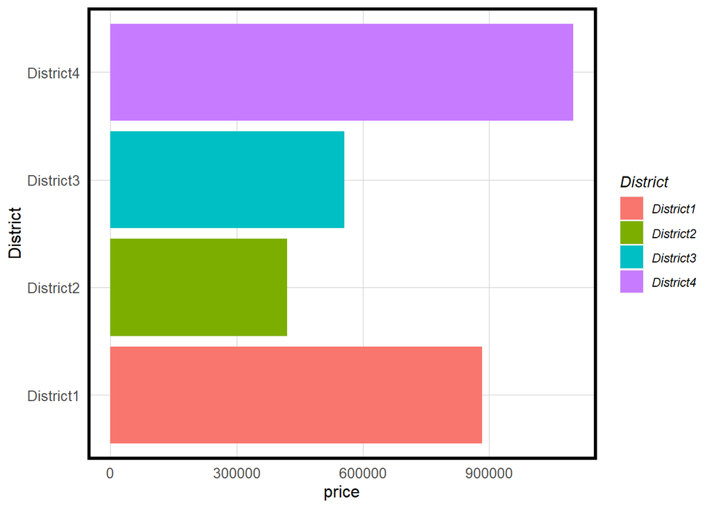

```r
st_drop_geometry(studentData) %>%
  select(price, District) %>%
  filter(price <= 5000000) %>%
  ggplot(aes(price, District)) +
  geom_bar(aes(fill = District), position = "dodge", stat = "summary", fun.y = "mean") +
  plotTheme()
```

### Price by Zip code

While it can be argued the zip code is correlated with school district, zip codes provide more nuanced data and are more publicly discussed than are census tracts. In this case there are a range of property price differences from each of the zip codes. Zip30 and and zip1 have higher values in comparison to the other zips. It is unclear if this is a random trend; however, there are stark enough differences in price, that it should be considered in the model.

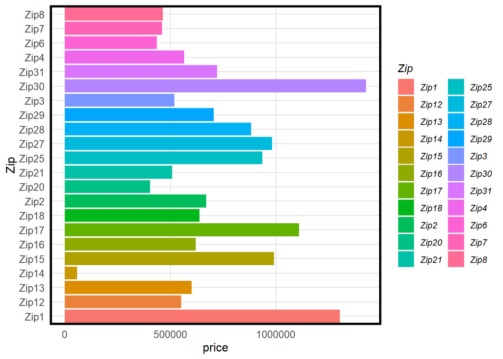

```r
st_drop_geometry(studentData) %>%
  select(price, Zip) %>%
  filter(price <= 5000000) %>%
  ggplot(aes(price, Zip)) +
  geom_bar(aes(fill = Zip), position = "dodge", stat = "summary", fun.y = "mean") +
  plotTheme()
```

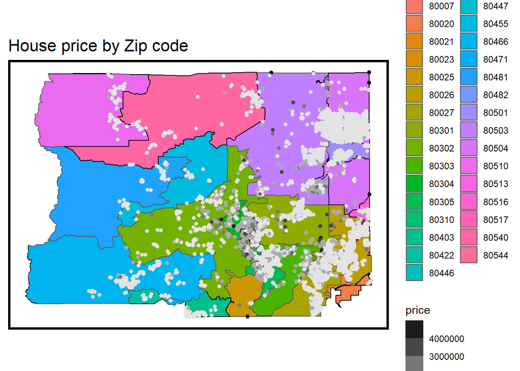

```r
ggplot() +
  geom_sf(data = acsZipsCol.2019.sf,
          aes(fill = GEOID)) +
  geom_sf(data = studentData %>% filter(price <= 5000000),
          aes(color = price)) +
  scale_color_steps(low="white", high="black", n.breaks = 5) +
  labs(title = "House price by Zip code") +
  mapTheme()
```

### Price by Racial Quartile

In engineering new data, we transformed census tracts racial categories by quartile to take into account how people from similar racial and ethnic backgrounds move to the similar locations.

#### White Quartile

The white quartile seemed to contradict general trends. It appears that the less white people there were the higher the price of the property.

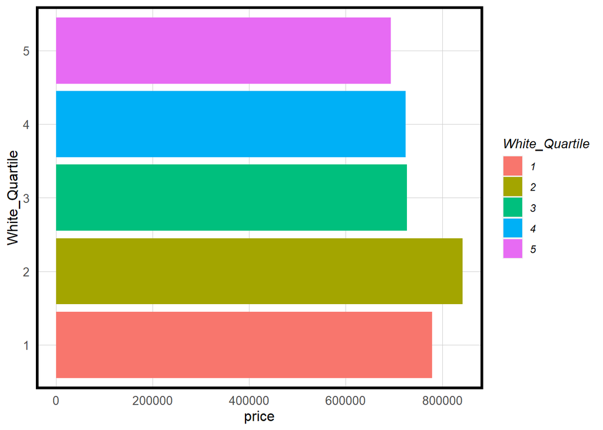

```r
st_drop_geometry(studentData) %>%
  select(price, White_Quartile) %>%
  filter(price <= 5000000) %>%
  ggplot(aes(price, White_Quartile)) +
  geom_bar(aes(fill = White_Quartile),position = "dodge", stat = "summary", fun.y = "mean") +
  plotTheme()
```

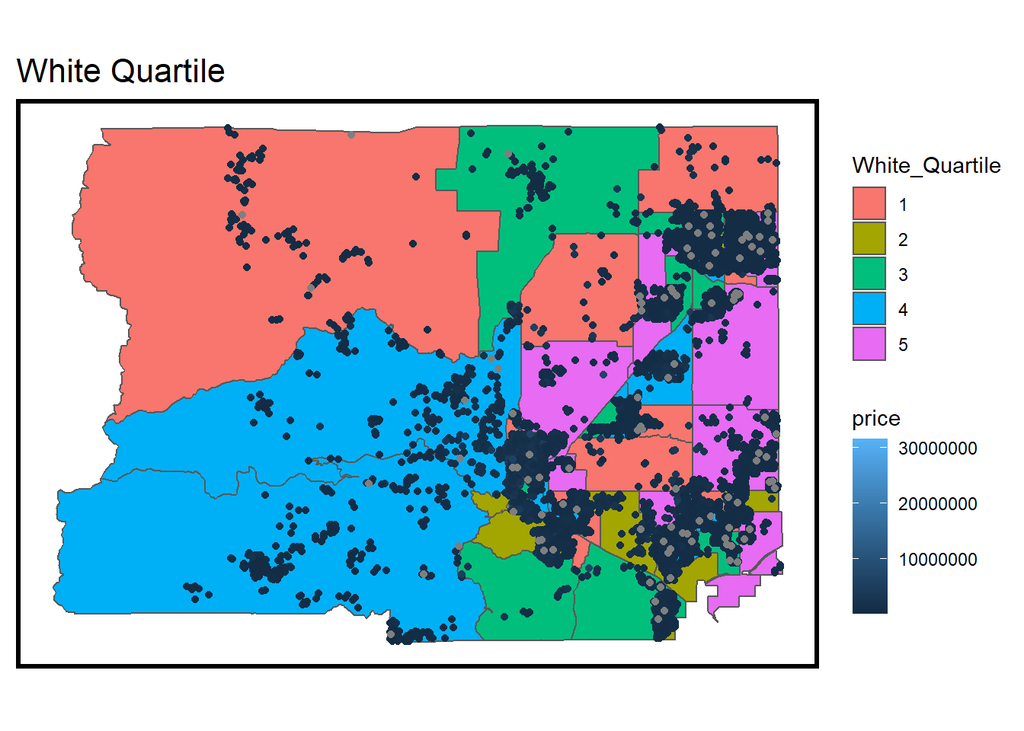

```r
ggplot() +
  geom_sf(data = acsTractsCol.2019.sf,
          aes(fill = White_Quartile)) +
  geom_sf(data = studentData,
          aes(color = price)) +
  labs(title = "White Quartile") +
  mapTheme()
```

#### Black Quartile

In contrast, to Black populations, in census tracts where there were median amounts of Black people, the housing prices were higher.

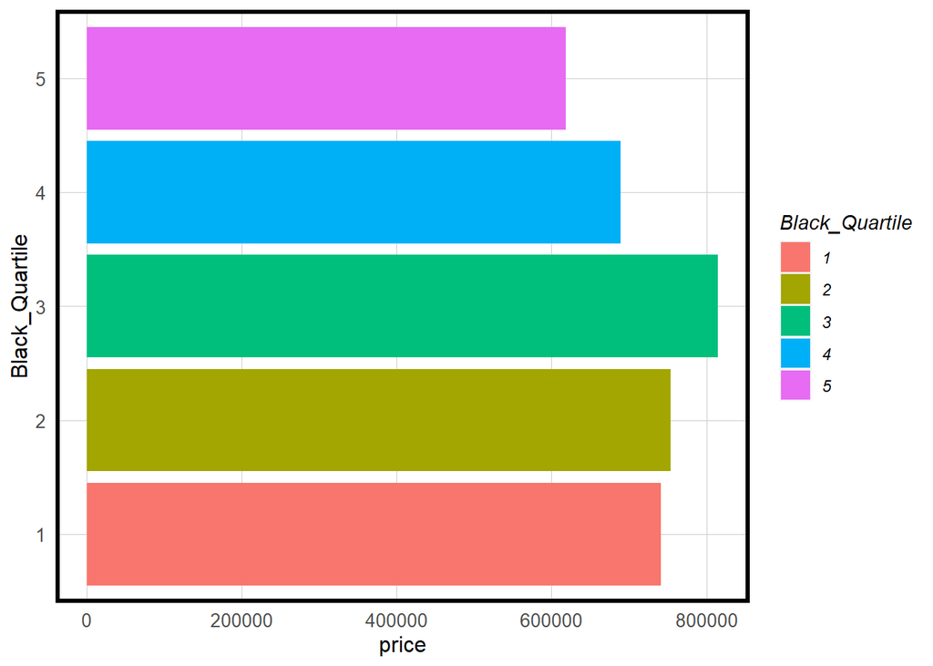

```r
st_drop_geometry(studentData) %>%
  select(price, Black_Quartile) %>%
  filter(price <= 5000000) %>%
  ggplot(aes(price, Black_Quartile)) +
  geom_bar(aes(fill = Black_Quartile),position = "dodge", stat = "summary", fun.y = "mean") +
  plotTheme()
```

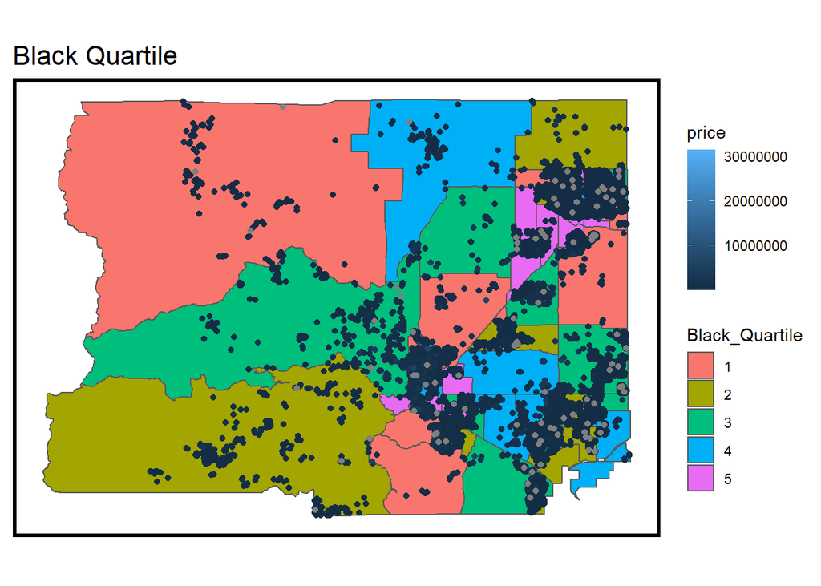

```r
ggplot() +
  geom_sf(data = acsTractsCol.2019.sf,
          aes(fill = Black_Quartile)) +
  geom_sf(data = studentData,
          aes(color = price)) +
  labs(title = "Black Quartile") +
  mapTheme()
```

#### Asian Quartile

The Asian Qaurtile provided the most stark differences in property values. Similar to white populations, where there were less Asians showed to be higher prices; however, it is important to note that in areas with many Asians the price still seemed to be high.

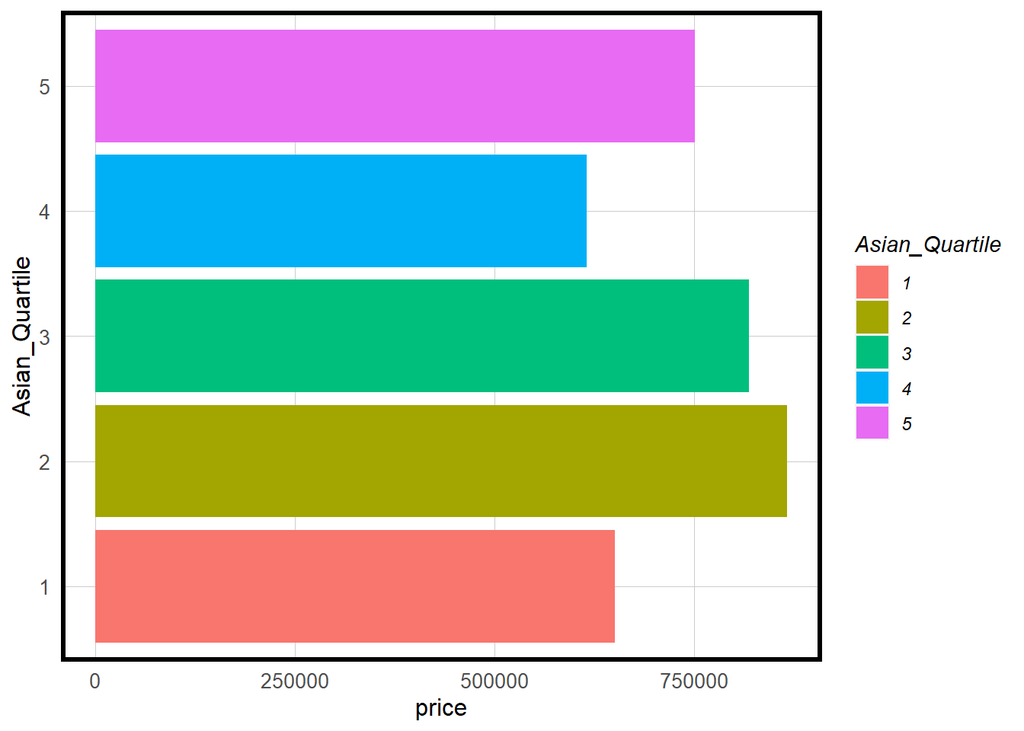

```r
st_drop_geometry(studentData) %>%
  select(price, Asian_Quartile) %>%
  filter(price <= 5000000) %>%
  ggplot(aes(price, Asian_Quartile)) +
  geom_bar(aes(fill = Asian_Quartile),position = "dodge", stat = "summary", fun.y = "mean") +
  plotTheme()
```

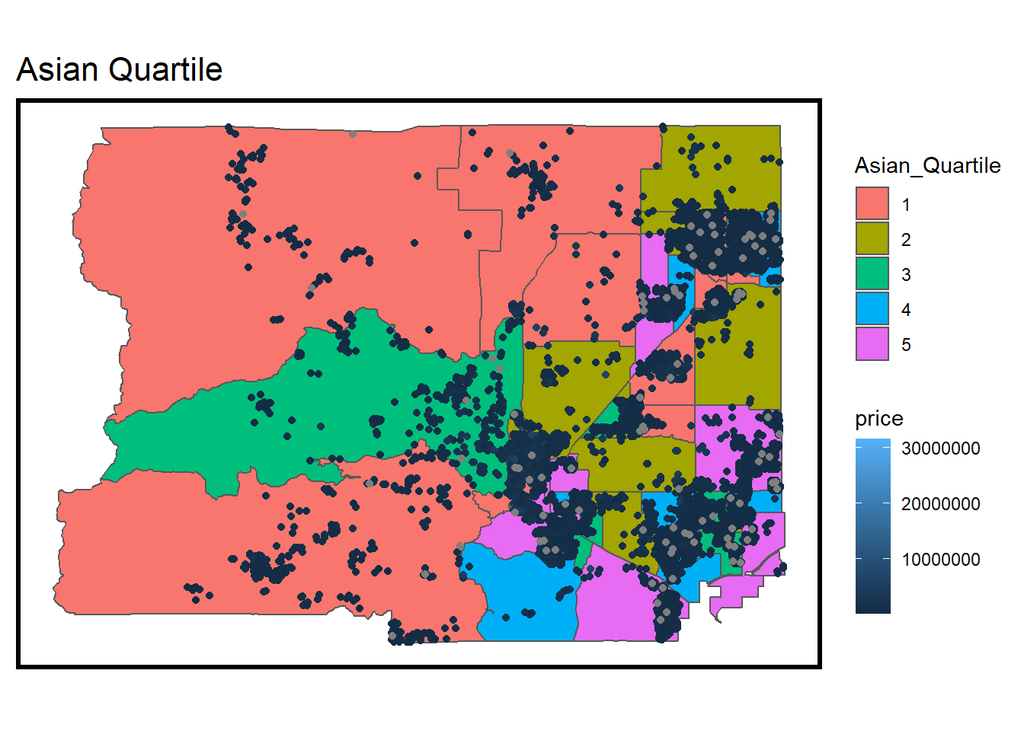

```r
ggplot() +
  geom_sf(data = acsTractsCol.2019.sf,
          aes(fill = Asian_Quartile)) +
  geom_sf(data = studentData,
          aes(color = price)) +
  labs(title = "Asian Quartile") +
  mapTheme()
```

#### American Indian Quartile

Finally in populations where there were less American Indians, there tended to be higher housing prices.

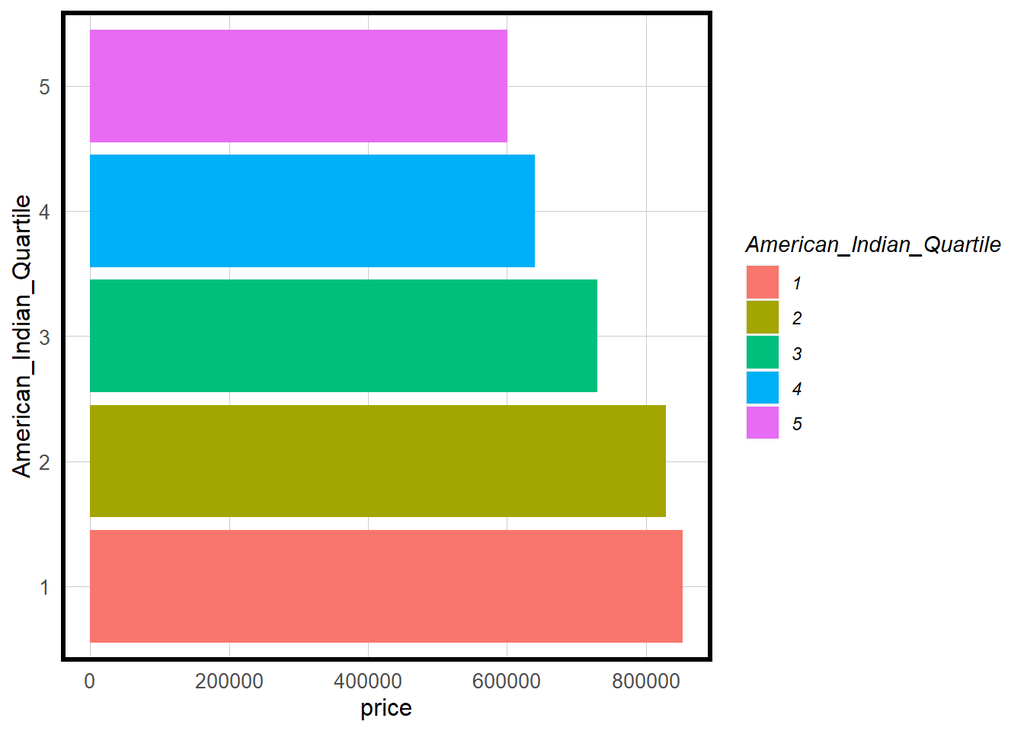

```r
st_drop_geometry(studentData) %>%
  select(price, American_Indian_Quartile) %>%
  filter(price <= 5000000) %>%
  ggplot(aes(price, American_Indian_Quartile)) +
  geom_bar(aes(fill = American_Indian_Quartile),position = "dodge", stat = "summary", fun.y = "mean") +
  plotTheme()
```

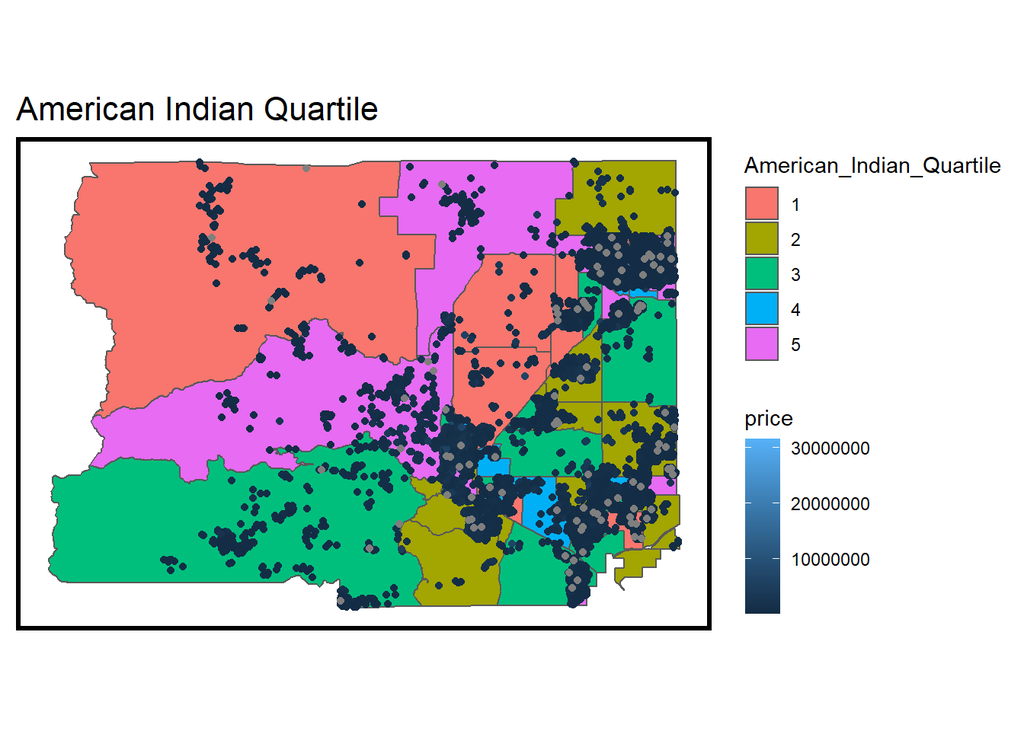

```r
ggplot() +
  geom_sf(data = acsTractsCol.2019.sf,
          aes(fill = American_Indian_Quartile)) +
  geom_sf(data = studentData,
          aes(color = price)) +
  labs(title = "American Indian Quartile") +
  mapTheme()
```

# Method

To develop our pricing model, we will be using multiple regression and cross-validation & goodness of fit to validate our model. This model uses a basic linear equation y = mx + b, where y is the predicted value, m is the slope, x is the variable and b is the intercept. In creating a model using multiple variables from our dataset, we add more variables to create m1x1 and m2x2 and so on. This allows us to create a model that can predict prices based on a linear model.

```r
# Find the average distance for nearest neighbors (1 thru 5) for three categories: Education, Amenities, and Public Services

# Change price where NA to 0 (so that toPredict houses are not omitted)
studentData$price <- na.replace(studentData$price, 0)

# Education
A <- bind_rows(
  st_drop_geometry(studentData) %>%
  filter(price < max(na.omit(studentData$price))) %>%
  select(1,MUSA_ID, starts_with("Edu")) %>%
  select(!starts_with("flood_pts")) %>%
  mutate(nn = "nn1") %>%
  pivot_longer(cols = ends_with("nn1"),
               names_to = "Amenities",
               values_to = "Distance"),
  st_drop_geometry(studentData) %>%
  filter(price < max(na.omit(studentData$price))) %>%
  select(1,MUSA_ID, starts_with("Edu")) %>%
  select(!starts_with("flood_pts")) %>%
      mutate(nn = "nn2") %>%
  pivot_longer(cols = ends_with("nn2"),
               names_to = "Amenities",
               values_to = "Distance"),
  st_drop_geometry(studentData) %>%
  filter(price < max(na.omit(studentData$price))) %>%
  select(1,MUSA_ID, starts_with("Edu")) %>%
  select(!starts_with("flood_pts")) %>%
      mutate(nn = "nn3") %>%
  pivot_longer(cols = ends_with("nn3"),
               names_to = "Amenities",
               values_to = "Distance"),
  st_drop_geometry(studentData) %>%
  filter(price < max(na.omit(studentData$price))) %>%
  select(1,MUSA_ID, starts_with("Edu")) %>%
  select(!starts_with("flood_pts")) %>%
      mutate(nn = "nn4") %>%
  pivot_longer(cols = ends_with("nn4"),
               names_to = "Amenities",
               values_to = "Distance"),
  st_drop_geometry(studentData) %>%
  filter(price < max(na.omit(studentData$price))) %>%
  select(1,MUSA_ID, starts_with("Edu")) %>%
  select(!starts_with("flood_pts")) %>%
      mutate(nn = "nn5") %>%
  pivot_longer(cols = ends_with("nn5"),
               names_to = "Amenities",
               values_to = "Distance")) %>%
  group_by(MUSA_ID) %>%
  summarize(Edu_mean_distance = mean(Distance))

studentData <- left_join(studentData, A, by = "MUSA_ID")

# Amenities
A <- bind_rows(
  st_drop_geometry(studentData) %>%
  filter(price < max(na.omit(studentData$price))) %>%
  select(1,MUSA_ID, starts_with("amenities")) %>%
  select(!starts_with("flood_pts")) %>%
  mutate(nn = "nn1") %>%
  pivot_longer(cols = ends_with("nn1"),
               names_to = "Amenities",
               values_to = "Distance"),
  st_drop_geometry(studentData) %>%
  filter(price < max(na.omit(studentData$price))) %>%
  select(1,MUSA_ID, starts_with("amenities")) %>%
  select(!starts_with("flood_pts")) %>%
      mutate(nn = "nn2") %>%
  pivot_longer(cols = ends_with("nn2"),
               names_to = "Amenities",
               values_to = "Distance"),
  st_drop_geometry(studentData) %>%
  filter(price < max(na.omit(studentData$price))) %>%
  select(1,MUSA_ID, starts_with("amenities")) %>%
  select(!starts_with("flood_pts")) %>%
      mutate(nn = "nn3") %>%
  pivot_longer(cols = ends_with("nn3"),
               names_to = "Amenities",
               values_to = "Distance"),
  st_drop_geometry(studentData) %>%
  filter(price < max(na.omit(studentData$price))) %>%
  select(1,MUSA_ID, starts_with("amenities")) %>%
  select(!starts_with("flood_pts")) %>%
      mutate(nn = "nn4") %>%
  pivot_longer(cols = ends_with("nn4"),
               names_to = "Amenities",
               values_to = "Distance"),
  st_drop_geometry(studentData) %>%
  filter(price < max(na.omit(studentData$price))) %>%
  select(1,MUSA_ID, starts_with("amenities")) %>%
  select(!starts_with("flood_pts")) %>%
      mutate(nn = "nn5") %>%
  pivot_longer(cols = ends_with("nn5"),
               names_to = "Amenities",
               values_to = "Distance")) %>%
  group_by(MUSA_ID) %>%
  summarize(amenities_mean_distance = mean(Distance))

studentData <- left_join(studentData, A, by = "MUSA_ID")

# Public Services
A <- bind_rows(
  st_drop_geometry(studentData) %>%
  filter(price < max(na.omit(studentData$price))) %>%
  select(1,MUSA_ID, starts_with("PS")) %>%
  select(!starts_with("flood_pts")) %>%
  mutate(nn = "nn1") %>%
  pivot_longer(cols = ends_with("nn1"),
               names_to = "Amenities",
               values_to = "Distance"),
  st_drop_geometry(studentData) %>%
  filter(price < max(na.omit(studentData$price))) %>%
  select(1,MUSA_ID, starts_with("PS")) %>%
  select(!starts_with("flood_pts")) %>%
      mutate(nn = "nn2") %>%
  pivot_longer(cols = ends_with("nn2"),
               names_to = "Amenities",
               values_to = "Distance"),
  st_drop_geometry(studentData) %>%
  filter(price < max(na.omit(studentData$price))) %>%
  select(1,MUSA_ID, starts_with("PS")) %>%
  select(!starts_with("flood_pts")) %>%
      mutate(nn = "nn3") %>%
  pivot_longer(cols = ends_with("nn3"),
               names_to = "Amenities",
               values_to = "Distance"),
  st_drop_geometry(studentData) %>%
  filter(price < max(na.omit(studentData$price))) %>%
  select(1,MUSA_ID, starts_with("PS")) %>%
  select(!starts_with("flood_pts")) %>%
      mutate(nn = "nn4") %>%
  pivot_longer(cols = ends_with("nn4"),
               names_to = "Amenities",
               values_to = "Distance"),
  st_drop_geometry(studentData) %>%
  filter(price < max(na.omit(studentData$price))) %>%
  select(1,MUSA_ID, starts_with("PS")) %>%
  select(!starts_with("flood_pts")) %>%
      mutate(nn = "nn5") %>%
  pivot_longer(cols = ends_with("nn5"),
               names_to = "Amenities",
               values_to = "Distance")) %>%
  group_by(MUSA_ID) %>%
  summarize(PS_mean_distance = mean(Distance))

studentData <- left_join(studentData, A, by = "MUSA_ID")

studentData$Edu_mean_distance <- as.integer(studentData$Edu_mean_distance)
studentData$amenities_mean_distance <- as.integer(studentData$amenities_mean_distance)
studentData$PS_mean_distance <- as.integer(studentData$PS_mean_distance)

studentData.training <- studentData %>%
    filter(toPredict == 0)

studentData.challenge <- studentData %>%
    filter(toPredict == 1)
```

## Data after feature engineering

Here is a summary table of all of our variables after feature engineering

### Internal Characteristics

Not all internal characteristics were added because they were categorical. The results would not yield meaningful analysis.

|  | Variables | n | mean | sd | min | max |
| --- | --- | --- | --- | --- | --- | --- |
| 1 | age | 11257 | 33.8337034733943 | 26.8004297058547 | 0 | 161 |
| 2 | bld_num | 11257 | 1.00763969085902 | 0.135066577395215 | 1 | 9 |
| 3 | bldgClass | 11257 | 1212 | 0 | 1212 | 1212 |
| 4 | bsmtSF | 11257 | 744.579639335525 | 627.622138378877 | 0 | 4534 |
| 5 | builtYear | 11257 | 1987.16629652661 | 26.8004297058547 | 1860 | 2021 |
| 6 | carStorageSF | 11257 | 471.651505729768 | 235.719445653255 | 0 | 3040 |
| 7 | CompCode | 11257 | 0.987621035799947 | 0.0953463607731291 | 0.1 | 1 |
| 8 | ConstCode | 11257 | 310.593408545794 | 18.4410064960086 | 0 | 420 |
| 9 | EffectiveYear | 11257 | 1997.69858754553 | 17.4778881208431 | 1879 | 2021 |
| 10 | iprvmntAge | 11257 | 10.5322910189216 | 18.4724831186983 | -3 | 129 |

[output cut: 13 more lines]

### Amenities and Public Services

```r
keep <- colnames(studentData[59:121])

A <- na.omit(studentData) %>%
  relocate(MUSA_ID,1) %>%
  select(1, where(is.numeric)) %>%
  st_drop_geometry() %>%
  pivot_longer(cols = 2:92,
               names_to = "Variables",
               values_to = "Values") %>%
  filter(Variables %in% keep) %>%
  group_by(Variables) %>%
    summarize(n = n(),
              mean = mean(Values),
              sd = sd(Values),
              min = min(Values),
              max = max(Values))

datatable(A)
```

|  | Variables | n | mean | sd | min | max |
| --- | --- | --- | --- | --- | --- | --- |
| 1 | amenities_dispensaries_nn1 | 11257 | 2606.69020223982 | 2641.41138819265 | 21.6581331464307 | 23910.7618379795 |
| 2 | amenities_dispensaries_nn2 | 11257 | 3235.86505373192 | 2943.51245337547 | 63.5481268889453 | 24142.1079701167 |
| 3 | amenities_dispensaries_nn3 | 11257 | 3675.1897552338 | 3154.46240344018 | 87.9437834871162 | 24558.2226012269 |
| 4 | amenities_dispensaries_nn4 | 11257 | 4004.01677731609 | 3295.05941349523 | 118.071426588409 | 25879.3960426315 |
| 5 | amenities_dispensaries_nn5 | 11257 | 4285.48254291806 | 3418.06413054049 | 141.199937370922 | 27306.7614824432 |
| 6 | amenities_grocery_nn1 | 11257 | 9047.22678238124 | 5437.71509916868 | 40.3645803372257 | 24628.3724162483 |
| 7 | amenities_grocery_nn2 | 11257 | 10389.7079478083 | 6158.36055697499 | 82.9601798014237 | 28147.610135898 |
| 8 | amenities_grocery_nn3 | 11257 | 10909.553117983 | 6406.51482624492 | 173.131097513746 | 29320.6893757813 |
| 9 | amenities_grocery_nn4 | 11257 | 11266.6377086403 | 6572.30992186546 | 225.427127701017 | 30097.6470933073 |
| 10 | amenities_grocery_nn5 | 11257 | 11520.0296581636 | 6647.84497726534 | 263.706263700451 | 30565.9303307389 |

[output cut: 53 more lines]

### Spatial Structures and Fixed Effects

Not all spatial structures were added because they were categorical. The results would not yield meaningful analysis.

```r
keep <- colnames(studentData[44:58])

A <- na.omit(studentData) %>%
  relocate(MUSA_ID,1) %>%
  select(1, where(is.numeric)) %>%
  st_drop_geometry() %>%
  pivot_longer(cols = 2:92,
               names_to = "Variables",
               values_to = "Values") %>%
  filter(Variables %in% keep) %>%
  group_by(Variables) %>%
    summarize(n = n(),
              mean = mean(Values),
              sd = sd(Values),
              min = min(Values),
              max = max(Values))

datatable(A)
```

|  | Variables | n | mean | sd | min | max |
| --- | --- | --- | --- | --- | --- | --- |
| 1 | Median_age | 11257 | 40.3482188860265 | 5.76241580645638 | 19.5 | 54.7 |
| 2 | Median_Female_age | 11257 | 41.1922714755263 | 6.08582968820308 | 19.3 | 58.4 |
| 3 | Median_Male_age | 11257 | 39.5374966687395 | 5.61520601719163 | 19.6 | 54.4 |
| 4 | withinCity | 11257 | 0.183441414231145 | 0.387045177471716 | 0 | 1 |

## Predictive Model Development

### Correlation matrix

To begin this process we first needed to determine what data was strongly correlated. Our definition of strongly correlated were any values that were greater the 0.7 and less the -0.7. These values were removed because they would not provide any new information to the model because they shared similarities to other values in the dataset. The correlation table only captures variables that are numeric. Next, we selected all the pairs of variables that had values between 0.6 and 0.3, and -0.6 and -0.3. These pairs of values were then sorted through to find only the unique combinations. From the unique combination of correlated pairs, we only selected the pairs that were correlated to price.

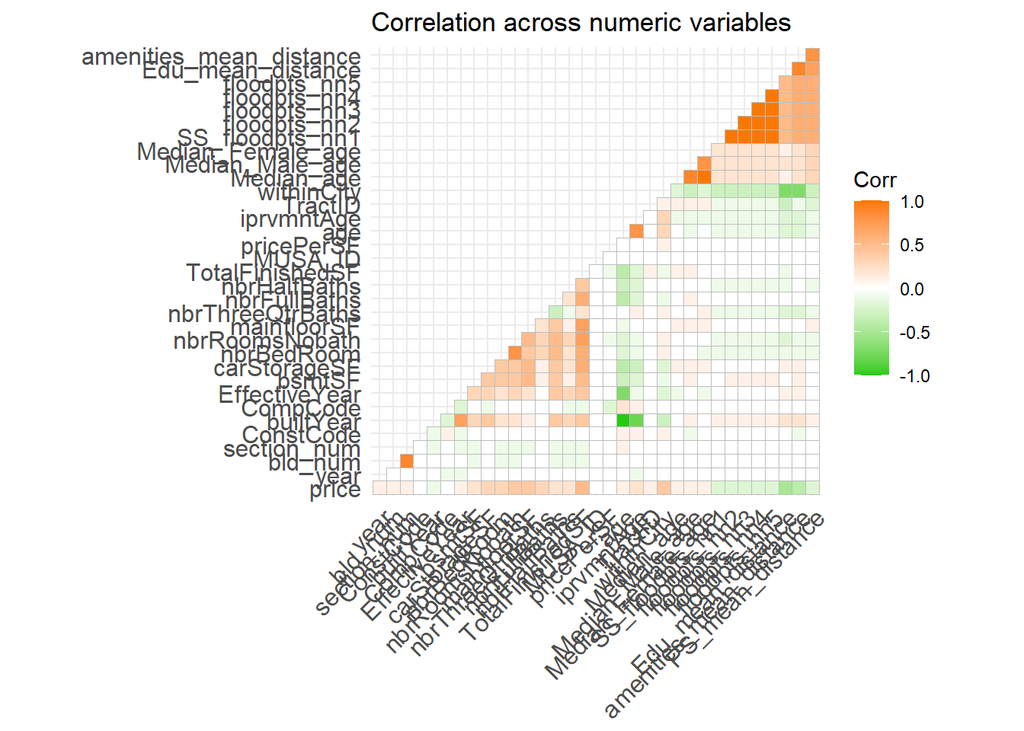

```r
numericVars <- studentData.training %>%
                  select(!contains("grocery")) %>%
                  select(!contains("restaurant")) %>%
                  select(!contains("Education")) %>%
                  select(!contains("Museums")) %>%
                  select(!contains("Library")) %>%
                  select(!contains("recreation")) %>%
                  select(!contains("pd")) %>%
                  select(!contains("fd_emt")) %>%
                  select(!contains("hospitals")) %>%
                  select(!contains("malls")) %>%
                  select(!contains("dispensaries")) %>%
                  select(!starts_with("qualityCode"))

numericVars <-
  st_drop_geometry(numericVars) %>%
  select(where(is.numeric)) %>%
  na.omit()

numericVars$Edu_mean_distance <- as.integer(numericVars$Edu_mean_distance)
numericVars$amenities_mean_distance <- as.integer(numericVars$amenities_mean_distance)
numericVars$PS_mean_distance <- as.integer(numericVars$PS_mean_distance)


numericVars <- numericVars %>%
  na.omit()

ggcorrplot(
  round(cor(numericVars), 1),
  p.mat = cor_pmat(numericVars),
  colors = c("#25CB10", "white", "#FA7800"),
  type="lower",
  insig = "blank") +
    labs(title = "Correlation across numeric variables")
```

```r
#trying to find variables that have a correlation value between 0.5 and -0.5
res <- as.data.frame(cor(numericVars)) %>%
rownames_to_column()

#pivot longer and sort through list
A <- res %>%
  select(!c("bldgClass","toPredict")) %>%
  slice(-c(6,21)) %>%
  pivot_longer(2:(ncol(res)-2)) %>%
  filter(value >= 0.3 & value <=0.6)

B <- res %>%
  select(!c("bldgClass","toPredict")) %>%
  slice(-c(6,21)) %>%
  pivot_longer(2:(ncol(res)-2)) %>%
  filter(value >= -0.6 & value <= -0.3)

corlist <- bind_rows(A,B)

corlist <- corlist %>%
  group_by(value) %>%
  arrange(desc(value))

#all odd numbers between 1 and 80
# Removes duplicates pairs that come from correlation matrix
keep <- c(1:nrow(corlist))
keep <- which(keep %% 2 == 1)

corlist <- corlist %>%
             slice(keep)

# includes all variables correlated with price
priceCor <- corlist %>%
  filter(rowname == "price")

keep <- priceCor$name

categorical <- colnames(studentData %>%
  select(where(is.factor)) %>%
    st_drop_geometry())


categorical <- c("Zip","District","price")
keep <- append(keep, categorical)
```

### Multiple regression

To develop our pricing model, we used multiple regression and cross-validation & goodness of fit to validate our model. This process consists of developing an equation that incorporates the variables for our internal characteristics, public services and amenities, and spatial process (fixed-effects) which draws the line of best fit (a line through the middle) of the dataset when it is plotted. Then, that equation is tested using various validation methods.

### Testing accuracy using MAE & MAPE

```r
set.seed(5)

inTrain <- createDataPartition(
              y = paste(studentData.training$district,
                        studentData.training$designCode,
                        studentData.training$Zip),
              times = 1,
              p = .70,
              list = FALSE)

training <- studentData.training[inTrain,]
test <- studentData.training[-inTrain,]

keep <- append(keep, "District")
reg.training <- lm(price ~ ., data = st_drop_geometry(training) %>%
                                    dplyr::select(keep))

#summary(reg.training)

test <- test %>%
  mutate(SalePrice.Predict = predict(reg.training, test),
         SalePrice.Error = SalePrice.Predict - price,
         SalePrice.AbsError = abs(SalePrice.Predict - price),
         SalePrice.APE = (abs(SalePrice.Predict - price)) / SalePrice.Predict)

mae <- mean(test$SalePrice.AbsError, na.rm=TRUE)
print(mae)
mape <- mean(test$SalePrice.APE, na.rm=TRUE)
print(mape)


# Table of regression outputs
modelsummary(reg.training, output = "kableExtra", stars = TRUE, gof_omit = 'IC|Log|AIC|BIC')
```

```
## [1] 198275.4
## [1] 0.2738717
```

|  | Model 1 |
| --- | --- |
| (Intercept) | 778940.198*** |
|  | (32381.228) |
| Edu_mean_distance | -58.611*** |
|  | (7.146) |
| amenities_mean_distance | 23.770* |
|  | (9.472) |
| nbrBedRoom | -22839.723*** |
|  | (6090.785) |
| withinCity | 18876.800 |
|  | (23517.562) |
| nbrRoomsNobath | 25733.061*** |
|  | (3372.159) |
| mainfloorSF | 135.355*** |
|  | (9.956) |
| TotalFinishedSF | 217.236*** |
|  | (8.104) |
| ZipZip12 | -735032.769*** |
|  | (185055.425) |
| ZipZip13 | -248259.387*** |
|  | (46426.223) |
| ZipZip14 | -522247.451 |
|  | (366497.463) |
| ZipZip15 | -333892.198*** |
|  | (29623.187) |
| ZipZip16 | -735339.327*** |
|  | (30267.964) |
| ZipZip17 | -475147.556* |
|  | (184646.287) |
| ZipZip18 | -511755.642*** |
|  | (25724.559) |
| ZipZip2 | -155926.035 |
|  | (142435.312) |
| ZipZip20 | -112116.261 |
|  | (225717.056) |
| ZipZip21 | -430610.522*** |
|  | (85990.604) |
| ZipZip25 | -281124.923+ |
|  | (165104.913) |
| ZipZip27 | -417359.057*** |
|  | (28791.555) |
| ZipZip28 | -505539.616*** |
|  | (27606.323) |
| ZipZip29 | -616039.662*** |
|  | (36662.085) |
| ZipZip3 | -495951.678*** |
|  | (42501.583) |
| ZipZip30 | 6309.103 |
|  | (26684.626) |
| ZipZip31 | -395941.579*** |
|  | (30703.516) |
| ZipZip4 | -300891.695*** |
|  | (54119.613) |
| ZipZip6 | -491327.054*** |
|  | (42709.957) |
| ZipZip7 | -525315.299*** |
|  | (67299.255) |
| ZipZip8 | -311566.664*** |
|  | (68035.452) |
| DistrictDistrict2 | 218747.043 |
|  | (217393.883) |
| DistrictDistrict3 | 117543.277*** |
|  | (25858.652) |
| DistrictDistrict4 | 359091.818+ |
|  | (187024.654) |
| Num.Obs. | 7920 |
| R2 | 0.553 |
| R2 Adj. | 0.551 |
| F | 314.828 |

+ p < 0.1, * p < 0.05, ** p < 0.01, *** p < 0.001

### Cross-Validation

Cross-validation provided similar values with R-squared and Mean Absolute Error which would be consistent with our model not being effective because of the Mean Absolute Error.

```r
fitControl <- trainControl(method = "cv", number = 100)
set.seed(825)

reg.cv <-
  train(price ~ ., data = st_drop_geometry(studentData.training) %>%
                                dplyr::select(keep),
     method = "lm", trControl = fitControl, na.action = na.pass)

reg.cv
```

```
## Linear Regression
##
## 11264 samples
##     9 predictor
##
## No pre-processing
## Resampling: Cross-Validated (100 fold)
## Summary of sample sizes: 11151, 11150, 11152, 11152, 11152, 11152, ...
## Resampling results:
##
##   RMSE      Rsquared   MAE
##   345712.1  0.5950529  197131.4
##
## Tuning parameter 'intercept' was held constant at a value of TRUE
```

### Predicting on Unseen Data

The code below uses the model we have developed to calculate the predicted house price for all homes in our dataset.

```r
# Predict house prices for all training data
studentData.training <- studentData.training %>%
  mutate(SalePrice.Predict = predict(reg.training, studentData.training))

# Predict house prices for challenge dataset
studentData.challenge <- studentData.challenge %>%
  mutate(SalePrice.Predict = predict(reg.training, studentData.challenge))


# Write challenge predictions to a csv
# predictions <- studentData.challenge %>%
#   st_drop_geometry() %>%
#   select(MUSA_ID, SalePrice.Predict) %>%
#   dplyr::rename(price = SalePrice.Predict)
#
# write.csv(predictions, "john2.csv")
```

### Map of Predicted home prices

The two maps below include predicted price.

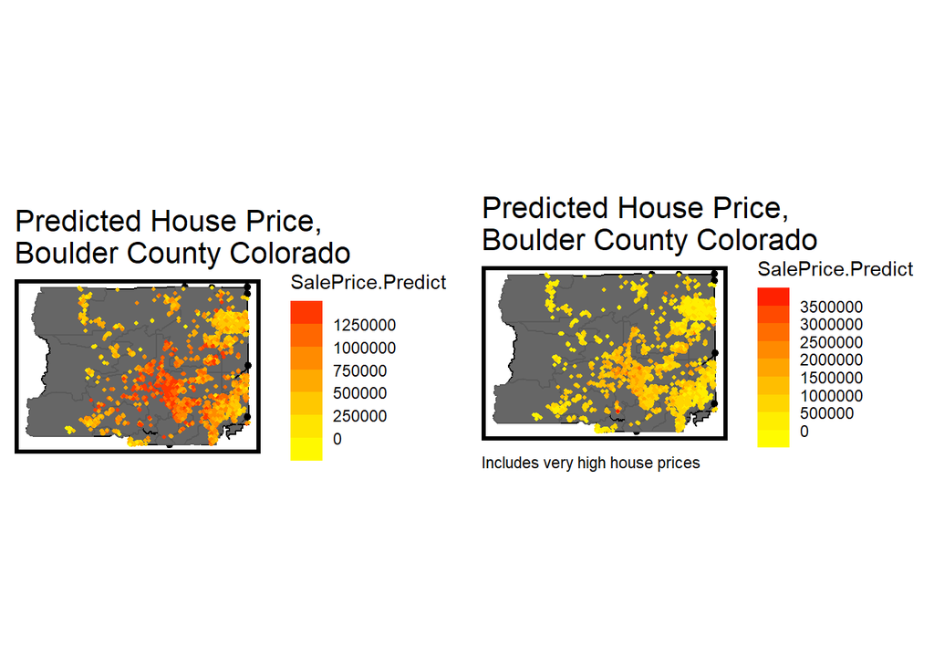

```r
totalPredictions <- rbind(studentData.challenge, studentData.training)

grid.arrange(ncol=2,
  ggplot() +
    geom_sf(data = acsZipsCol.2019.sf, fill = "grey40") +
    geom_sf(data = totalPredictions %>% filter(SalePrice.Predict< 1500000), aes(colour = SalePrice.Predict),
            show.legend = "point", size = .75) +
    scale_color_steps(low="yellow", high="red", n.breaks = 8)  +
    labs(title="Predicted House Price,\nBoulder County Colorado") +
    mapTheme(),
  ggplot() +
    geom_sf(data = acsZipsCol.2019.sf, fill = "grey40") +
    geom_sf(data = totalPredictions, aes(colour = SalePrice.Predict),
            show.legend = "point", size = .75) +
    scale_color_steps(low="yellow", high="red", n.breaks = 8)  +
    labs(title="Predicted House Price,\nBoulder County Colorado",
          caption = paste0("Includes very high house prices")
         ) +
    mapTheme()
  )
```

### Predicted home prices as a function of actual home price

These figures illustrate that as houses is no longer effective at predicting house prices above $2 million. Perhaps this is because most of the training data are for houses that are more affordable, and therefore the model is able to more accurately predict those prices.

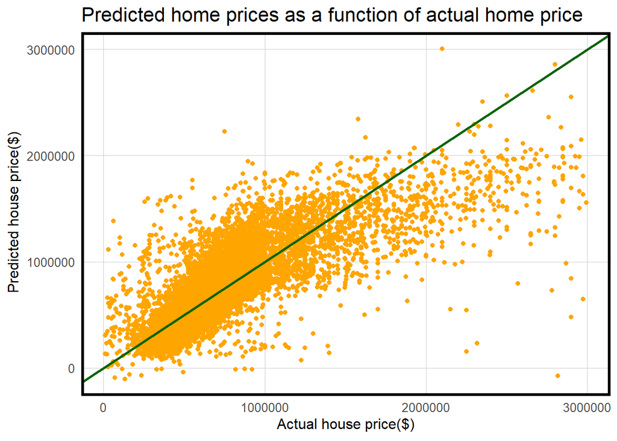

```r
studentData.training %>%
  select(SalePrice.Predict, price) %>%
  filter(price < 3000000) %>%
  ggplot(aes(price, SalePrice.Predict)) +
    geom_point(color = "orange") +
    geom_abline(color = "dark green",
                size = 1 ) +
    labs(title = "Predicted home prices as a function of actual home price",
         x = expression("Actual house price($)"),
         y = expression("Predicted house price($)") ) +
  plotTheme()
```

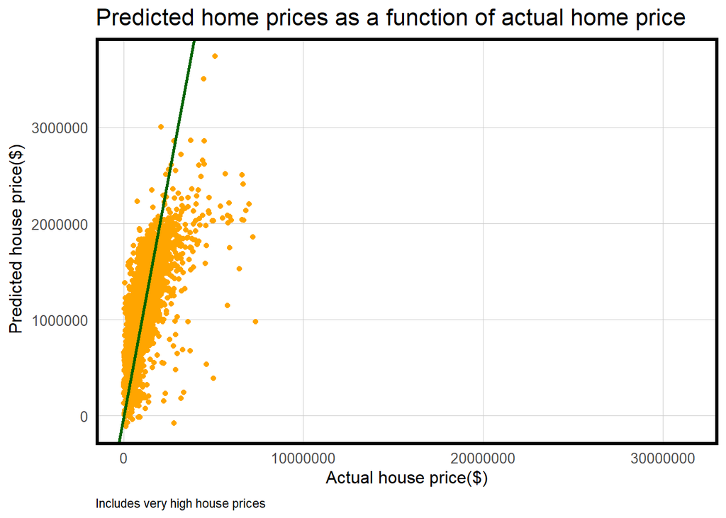

```r
studentData.training %>%
  select(SalePrice.Predict, price) %>%
  ggplot(aes(price, SalePrice.Predict)) +
    geom_point(color = "orange") +
    geom_abline(color = "dark green",
                size = 1) +
    labs(title = "Predicted home prices as a function of actual home price",
          caption = paste0("Includes very high house prices"),
          x = expression("Actual house price($)"),
          y = expression("Predicted house price($)")) +
  plotTheme()
```

### Map of residuals for the test set

The figure below maps the residuals, the difference betweeen the predicted price and actual price. In brief, this is an indicator of the model’s accuracy.

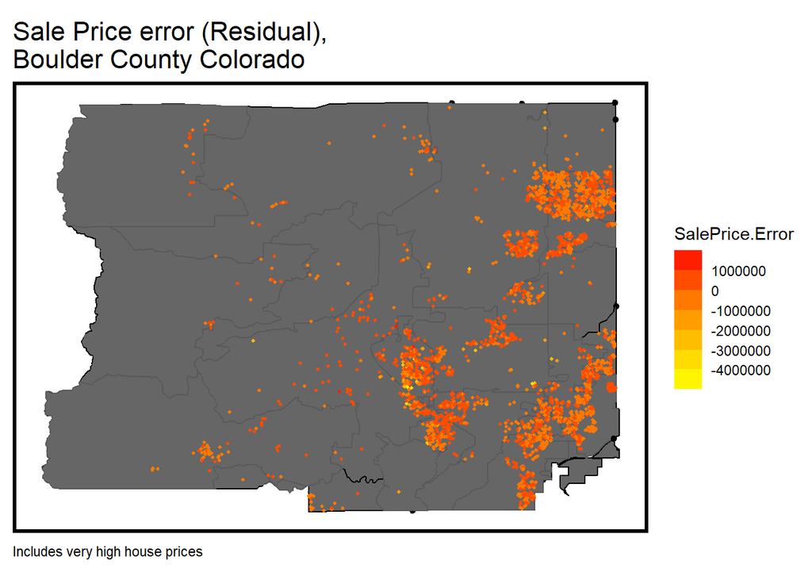

```r
ggplot() +
    geom_sf(data = acsZipsCol.2019.sf, fill = "grey40") +
    geom_sf(data = test, aes(colour = SalePrice.Error),
            show.legend = "point", size = .75) +
    scale_color_steps(low="yellow", high="red", n.breaks = 8)  +
    labs(title="Sale Price error (Residual),\nBoulder County Colorado",
          caption = paste0("Includes very high house prices")
         ) +
    mapTheme()
```

### Do prices and errors cluster - spatial lag & testing for SA in our current model

This graph belows shows that there is still spatial autocorrelation that has not been accounted for. As the lag error price increases or decreases the home prices around it should also move similarly.

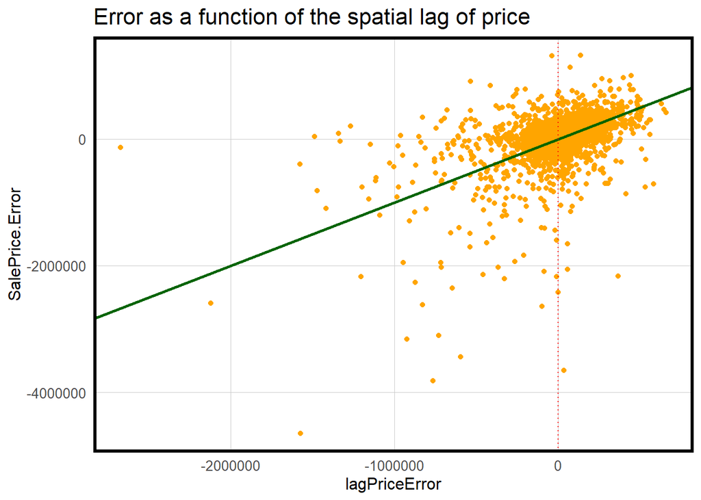

```r
coords.test <-  st_coordinates(test)

neighborList.test <- knn2nb(knearneigh(coords.test, 5))

spatialWeights.test <- nb2listw(neighborList.test, style="W")

test %>%
  mutate(lagPriceError = lag.listw(spatialWeights.test, SalePrice.Error)) %>%
  ggplot(aes(lagPriceError, SalePrice.Error)) +
  geom_point(color = "orange") +
  geom_abline(color = "dark green",
              size = 1) +
  geom_vline(xintercept = 0,
             color = "red",
             linetype = "dotted") +
  labs(title = "Error as a function of the spatial lag of price") +
  plotTheme()
```

### Moran’s I

Moran’s I is a test for spatial autocorrelation in the errors of our model. Spatial autocorrelation is the clustering of similar things in space. If the errors of the model are clustered in space, it means the model is not able to fully account for the clustering of house prices. The figure below shows the clustering of randomized errors in the gray and the observed Moran’s I of our model in orange. In and ideal scenario, the observed Moran’s I line would be located within the distribution of the randomized Moran’s I distribution. However, it is evident that there is still spatial autocorrelation in house prices that is unaccounted for in our model.

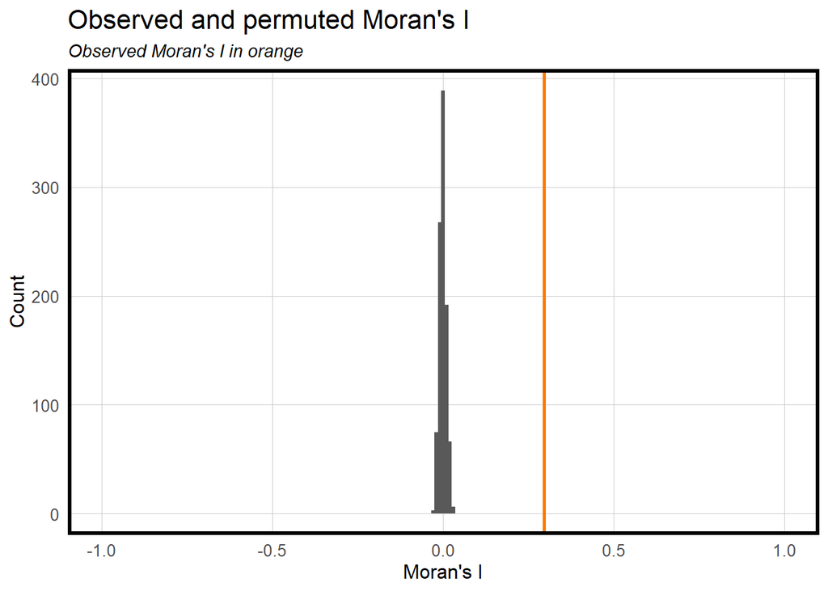

```r
moranTest <- moran.mc(test$SalePrice.Error,
                      spatialWeights.test, nsim = 999)

ggplot(as.data.frame(moranTest$res[c(1:999)]), aes(moranTest$res[c(1:999)])) +
  geom_histogram(binwidth = 0.01) +
  geom_vline(aes(xintercept = moranTest$statistic), colour = "#FA7800",size=1) +
  scale_x_continuous(limits = c(-1, 1)) +
  labs(title="Observed and permuted Moran's I",
       subtitle= "Observed Moran's I in orange",
       x="Moran's I",
       y="Count") +
  plotTheme()
```

### MAPE by neighborhood

Another method of testing the predictive power of our model is visualizing the Mean Absolute Percent Errors (MAPE) by spatial unit, in this case, zip codes. MAPE’s that are low are considered to be better as it indicates that there is less error in the model. The figure below illustrates that there are zip codes in which the model performs much better than others. Perhaps this is linked to the model’s reduced effectiveness with higher-priced homes. This conclusion is backed up by the scatter plot below. The neighborhood with the highest average price has the highest MAPE.

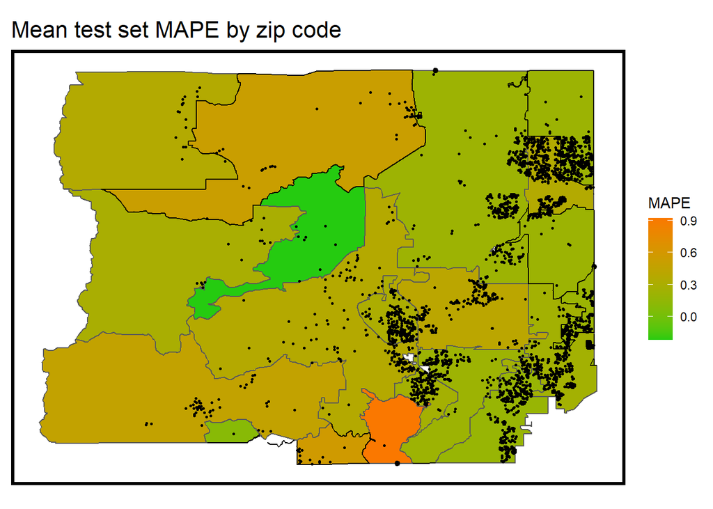

```r
test <- test %>%
  st_join(., acsZipsCol.2019.sf, join=st_intersects) %>%
  dplyr::select(!c(127:161))

# Spatially visulaize MAPE by neighborhood
st_drop_geometry(test) %>%
  group_by(GEOID) %>%
  summarize(mean.MAPE = mean(SalePrice.APE, na.rm = T)) %>%
  ungroup() %>%
  left_join(acsZipsCol.2019.sf, by = c("GEOID" = "GEOID")) %>%
    st_sf() %>%
    ggplot() +
      geom_sf(aes(fill = mean.MAPE)) +
      geom_sf(data = test, colour = "black", size = .5) +
      scale_fill_gradient(low = palette5[1], high = palette5[5],
                          name = "MAPE") +
      labs(title = "Mean test set MAPE by zip code") +
      mapTheme()
```

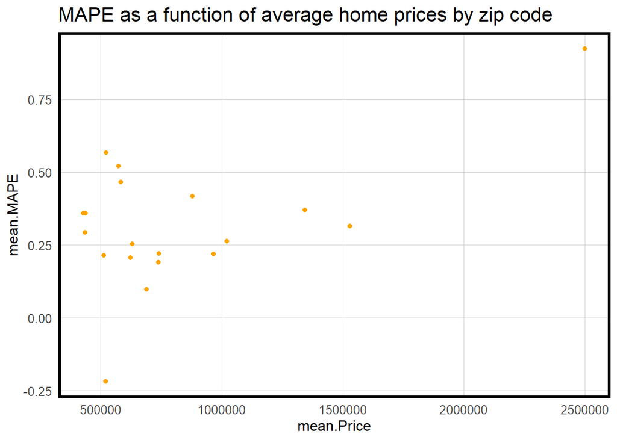

```r
# Scatter plot of MAPE by neighborhood as a function of mean price by neighborhood
test %>%
  st_drop_geometry() %>%
  select(SalePrice.APE, price, Zip) %>%
  # filter(price < 3000000) %>%
  group_by(Zip) %>%
  summarize(mean.MAPE = mean(SalePrice.APE, na.rm = T), mean.Price = mean(price, na.rm= T)) %>%
  ggplot(aes(mean.Price, mean.MAPE)) +
    geom_point(color = "orange") +
    geom_abline(color = "dark green", size = 1) +
  labs(title = "MAPE as a function of average home prices by zip code") +
  plotTheme()
```

### Over/Under prediction through racial and economic lense

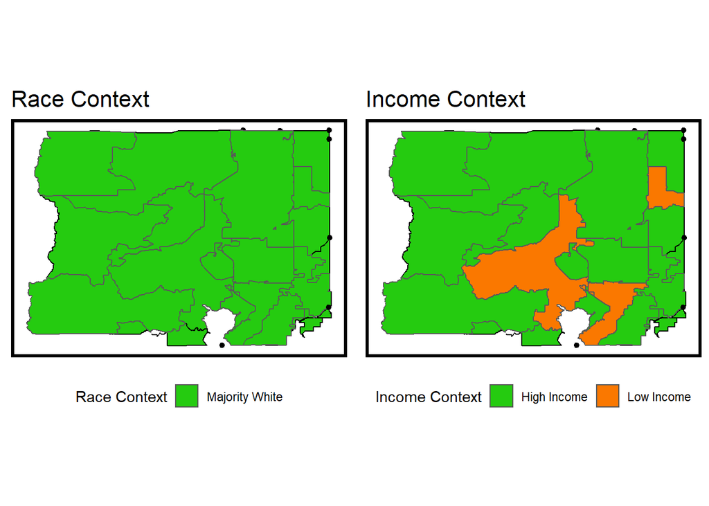

```r
acsZipsCol.2019.sf <- acsZipsCol.2019.sf %>%
  mutate(percentWhite = White_pop / Total_pop,
         raceContext = ifelse(percentWhite > .5, "Majority White", "Majority Non-White"),
         incomeContext = ifelse(Median_Income > 32322, "High Income", "Low Income"))

# map of racial and income distribution
grid.arrange(ncol = 2,
  ggplot() + geom_sf(data = na.omit(acsZipsCol.2019.sf), aes(fill = raceContext)) +
    scale_fill_manual(values = c("#25CB10", "#FA7800"), name="Race Context") +
    labs(title = "Race Context") +
    mapTheme() + theme(legend.position="bottom"),
  ggplot() + geom_sf(data = na.omit(acsZipsCol.2019.sf), aes(fill = incomeContext)) +
    scale_fill_manual(values = c("#25CB10", "#FA7800"), name="Income Context") +
    labs(title = "Income Context") +
    mapTheme() + theme(legend.position="bottom"))
```

```r
# Evaluation of Over or Under Prediction of model on
A <- st_join(test, acsZipsCol.2019.sf) %>%
  group_by(incomeContext) %>%
  summarize(mean.MAPE = scales::percent(mean(SalePrice.APE, na.rm = T))) %>%
  st_drop_geometry() %>%
  spread(incomeContext, mean.MAPE)

A <- A %>%
  rename("No Data" = 3)
datatable(A)
```

|  | High Income | Low Income | No Data |
| --- | --- | --- | --- |
| 1 | 26% | 34% | 92% |

# Discussion

# Conclusion

We would not recommend this model over Zillow’s existing model for a few reasons. As mentioned above, there are issues with the model’s ability to predict on higher value houses and account for existing spatial autocorrelation. Further, the model’s errors are much higher than [Zillow’s advertised error](https://www.zillow.com/z/zestimate/). Further, we have not tested this model outside of Boulder. We do not know if this model will be generalizable to other markets.